# Calculating Walking and cycling trips impedance function- 2010

# Active-transport walking and cycling behaviour in Canada

## Data and Method

Data on walking and cycling trips to different destinations was derived from Canada’s General Social Survey (GSS) from 1986 to 2015. GSS is a social trends survey in order to monitor changes in the living conditions and well-being of Canadians and to provide information on specific social policy issues. one of the important information of GSS is about Time-use surveys. This survey collects information on all human activities and can therefore inform a broad range of policies. Statistics Canada has been conducting time-use surveys since 1986 at approximately five- to seven- year intervals, most recently in 2015.The GSS on time use employs a retrospective 24-hour time diary to collect information on respondents’ participation in, and time spent on, a wide variety of day-to-day activities. In addition, information is collected on the location where these activities occurred (e.g., at home, at work, etc.).in addition, This dataset contains travel time data of Many of the Census Metropolitan Areas (CMAs) and non-CMA areas all over Canada. CMAs are including St. John’s, Halifax, Saint John, Montreal, Quebec City, Toronto, Ottawa, Hamilton, Winnipeg, Regina, Saskatoon, Calgary, Edmonton, and Vancouver. and the non-CMA areas of each of the ten provinces were also grouped to form ten more strata.

# Result

First load all of the libraries

Here, we are loading all the primary files of the GSS dataset to create our database for analysis.

### Calculating impedance function for walking in 2010

```r
count <- sum(walking_2010$DURATION > 100)
print (count)
```

```
[1] 19
```

```r
walking_2010 <- walking_2010 %>% filter(DURATION < 100)
summary(walking_2010$DURATION)
```

```
   Min. 1st Qu.  Median    Mean 3rd Qu.    Max.
   0.00    5.00    8.00   11.69   15.00   90.00
```

using a skew vs. kurtois graph to descriptive statistics of data:

```r
# creating a skew vs. kurtois graph for walking 2010

descdist(walking_2010$DURATION %>% unlist() %>% as.numeric(), discrete=FALSE, boot=500)
```

[output not shown]

```r
# The Duration column contains eight zero values. Before proceeding to calculate the gamma, exponential, lognormal and weibull distribution, a preprocessing step was undertaken, converting these zero values to the value of five.

# change 0 value to 5
walking_2010$DURATION[walking_2010$DURATION == 0] <- 5

# Based on the skew vs. kurtois graph the best distribution

#Calculating gamma distribution

gamma_w_2010_ <- fitdistrplus::fitdist(data=walking_2010$DURATION%>% unlist() %>% as.numeric(), "gamma", method="mle", optim.method="Nelder-Mead", weights = round(walking_2010$WGHT_EPI))

fit_dgamma <- data.frame(f = dgamma(walking_2010$DURATION, shape = gamma_w_2010_$estimate[1], rate = gamma_w_2010_$estimate[2]), x = walking_2010$DURATION, type = "Gamma")

summary(gamma_w_2010_)

plot(x= fit_dgamma$x, y=fit_dgamma$f)

#Calculating weibull distribution
weibull_w_2010_ <- fitdistrplus::fitdist(data=walking_2010$DURATION%>% unlist() %>% as.numeric(), "weibull", method="mle", optim.method="Nelder-Mead", weights = round(walking_2010$WGHT_EPI))

summary(weibull_w_2010_)

fit_dweibull <- data.frame(f = dweibull(walking_2010$DURATION, shape = weibull_w_2010_$estimate[1], scale = weibull_w_2010_$estimate[2]), x = walking_2010$DURATION, type = "weibull")

plot(x= fit_dweibull$x, y=fit_dweibull$f)


#Calculating exponential distribution
exp_w_2010_ <- fitdistrplus::fitdist(data=walking_2010$DURATION%>% unlist() %>% as.numeric(), "exp", method="mle", optim.method="Nelder-Mead", weights = round(walking_2010$WGHT_EPI))

summary(exp_w_2010_)

# Get the estimated rate parameter from the fitted distribution
rate_estimate <- exp_w_2010_$estimate[1]

# Create a data frame for the fitted exponential distribution
fit_dexp <- data.frame(f = dexp(walking_2010$DURATION, rate = rate_estimate),
                       x = walking_2010$DURATION, type = "exp")

# Plot the fitted exponential distribution
plot(x = fit_dexp$x, y = fit_dexp$f)

#Calculating lognormal distribution
lnorm_w_2010_ <- fitdistrplus::fitdist(data=walking_2010$DURATION%>% unlist() %>% as.numeric(), "lnorm", method="mle", optim.method="Nelder-Mead", weights = round(walking_2010$WGHT_EPI))

summary(lnorm_w_2010_)

fit_dlnorm <- data.frame(f = dlnorm(walking_2010$DURATION, meanlog = lnorm_w_2010_$estimate[1], sdlog = lnorm_w_2010_$estimate[2]), x = walking_2010$DURATION, type = "lnorm")

plot(x= fit_dlnorm$x, y=fit_dlnorm$f)
```

[output not shown]

Now let’s compare these models based on AIC and BIC to see which fits the walking 2010 data best:

```r
#comparing these models AIC and BIC to see which fits the walk data best:
broom::glance(MASS::fitdistr(walking_2010$DURATION%>% unlist() %>% as.numeric(),"gamma"))
broom::glance(MASS::fitdistr(walking_2010$DURATION%>% unlist() %>% as.numeric(),"weibull"))
broom::glance(MASS::fitdistr(walking_2010$DURATION%>% unlist() %>% as.numeric(),"exponential"))
broom::glance(MASS::fitdistr(walking_2010$DURATION%>% unlist() %>% as.numeric(),"lognormal"))
```

[output not shown]

```r
# Load and define walking_2010_lnorm if not already defined
walking_2010_lnorm <- lnorm_w_2010_

# Perform the mutation using the dlnorm function
walking_2010 <- walking_2010 %>%
  mutate(f = dlnorm(DURATION, meanlog = walking_2010_lnorm$estimate["meanlog"],
                    sdlog = walking_2010_lnorm$estimate["sdlog"]))

# Print summary of the new 'f' variable
summary(walking_2010$f)
```

```
     Min.   1st Qu.    Median      Mean   3rd Qu.      Max.
0.0002044 0.0216105 0.0463698 0.0469349 0.0732770 0.0846277
```

### Calculating impedance function for walking in 2010 based on different purposes

###Destination : Home (1) - 2010

using a skew vs. kurtois graph to descriptive statistics of data

```r
# creating a skew vs. kurtois graph for walking 2010

# Filter the data based on the "destination" column
 w_1_2010 <- walking_2010 %>%
  filter(destination == "1")
descdist(w_1_2010$DURATION %>% unlist() %>% as.numeric(), discrete=FALSE, boot=500)
```

[output not shown]

```r
# Based on the skew vs. kurtois graph the best distribution

#Calculating gamma distribution
gamma_w1_2010_ <- fitdistrplus::fitdist(data=w_1_2010$DURATION%>% unlist() %>% as.numeric(), "gamma", method="mle", optim.method="Nelder-Mead", weights = round(w_1_2010$WGHT_EPI))
fit_dgamma_w110 <- data.frame(f = dgamma(w_1_2010$DURATION, shape = gamma_w1_2010_$estimate[1], rate = gamma_w1_2010_$estimate[2]), x = w_1_2010$DURATION, type = "Gamma")

summary(gamma_w1_2010_)
```

```
Fitting of the distribution ' gamma ' by maximum likelihood
Parameters :
```

|  | estimate | Std. Error |
| --- | --- | --- |
| shape | 1.22892718 | 8.627524e-04 |
| rate | 0.08739856 | 7.530176e-05 |

```
Loglikelihood:  -11829779   AIC:  23659561   BIC:  23659572
Correlation matrix:
          shape      rate
shape 1.0000000 0.8146374
rate  0.8146374 1.0000000
```

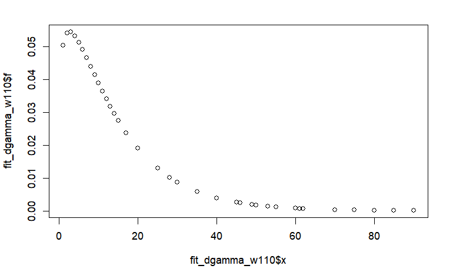

```r
plot(x= fit_dgamma_w110$x, y=fit_dgamma_w110$f)
```

```r
#Calculating weibull distribution
weibull_w1_2010_ <- fitdistrplus::fitdist(data=w_1_2010$DURATION%>% unlist() %>% as.numeric(), "weibull", method="mle", optim.method="Nelder-Mead", weights = round(w_1_2010$WGHT_EPI))
summary(weibull_w1_2010_)
```

```
Fitting of the distribution ' weibull ' by maximum likelihood
Parameters :
```

|  | estimate | Std. Error |
| --- | --- | --- |
| shape | 1.086337 | 0.0004504437 |
| scale | 14.554959 | 0.0078580200 |

```
Loglikelihood:  -11851543   AIC:  23703090   BIC:  23703101
Correlation matrix:
         shape    scale
shape 1.000000 0.328114
scale 0.328114 1.000000
```

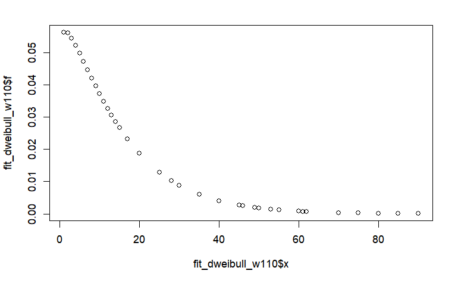

```r
fit_dweibull_w110 <- data.frame(f = dweibull(w_1_2010$DURATION, shape = weibull_w1_2010_$estimate[1], scale = weibull_w1_2010_$estimate[2]), x = w_1_2010$DURATION, type = "weibull")

plot(x= fit_dweibull_w110$x, y=fit_dweibull_w110$f)
```

```r
#Calculating exponential distribution
exp_w1_2010_ <- fitdistrplus::fitdist(data=w_1_2010$DURATION%>% unlist() %>% as.numeric(), "exp", method="mle", optim.method="Nelder-Mead", weights = round(w_1_2010$WGHT_EPI))
summary(exp_w1_2010_)
```

```
Fitting of the distribution ' exp ' by maximum likelihood
Parameters :
```

|  | estimate | Std. Error |
| --- | --- | --- |
| rate | 0.07110557 | 3.938625e-05 |

```
Loglikelihood:  -11870549   AIC:  23741100   BIC:  23741106
```

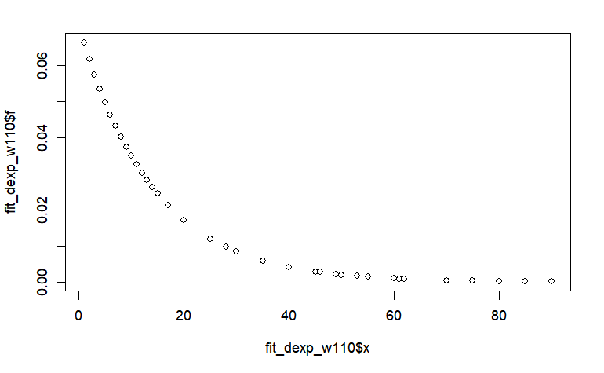

```r
fit_dexp_w110 <- data.frame(f = dexp(w_1_2010$DURATION, rate = exp_w1_2010_$estimate[1]),
                       x = w_1_2010$DURATION, type = "exp")

plot(x = fit_dexp_w110$x, y = fit_dexp_w110$f)
```

Now let’s compare these models AIC and BIC to see which fits the walk data best:

```r
#comparing these models AIC and BIC to see which fits the walk data best:
broom::glance(MASS::fitdistr(w_1_2010$DURATION%>% unlist() %>% as.numeric(),"gamma"))
```

| logLik | AIC | BIC | nobs |
| --- | --- | --- | --- |
| -6773.818 | 13551.64 | 13562.73 | 1899 |

```r
broom::glance(MASS::fitdistr(w_1_2010$DURATION%>% unlist() %>% as.numeric(),"weibull"))
```

| logLik | AIC | BIC | nobs |
| --- | --- | --- | --- |
| -6785.956 | 13575.91 | 13587.01 | 1899 |

```r
broom::glance(MASS::fitdistr(w_1_2010$DURATION%>% unlist() %>% as.numeric(),"exponential"))
```

| logLik | AIC | BIC | nobs |
| --- | --- | --- | --- |
| -6791.864 | 13585.73 | 13591.28 | 1899 |

So, gamma has largest logLik and the smallest AIC and BIC. we will pick gamma function for walking trips in 2010!

```r
walking_110_gamma <- gamma_w1_2010_
w_1_2010 <- w_1_2010 %>%
 mutate(f_1 = dgamma(DURATION, walking_110_gamma$estimate["shape"], walking_110_gamma$estimate["rate"]))
summary(w_1_2010$f_1)
```

```
     Min.   1st Qu.    Median      Mean   3rd Qu.      Max.
5.901e-05 2.751e-02 3.882e-02 3.673e-02 5.127e-02 5.433e-02
```

###Destination : work or school (2 and 8)

using a skew vs. kurtois graph to descriptive statistics of data

```
summary statistics
------
min:  1   max:  80
median:  10
mean:  11.75878
estimated sd:  10.89173
estimated skewness:  2.156612
estimated kurtosis:  9.503467
```

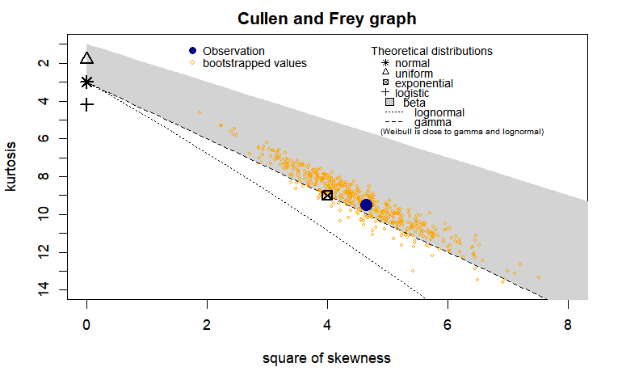

```r
# creating a skew vs. kurtois graph for walking 2010

# Filter the data based on the "destination" column
 w_2_2010 <- walking_2010 %>%
  filter(destination %in% c("2", "8"))
descdist(w_2_2010$DURATION %>% unlist() %>% as.numeric(), discrete=FALSE, boot=500)
```

As shown in the Cullen and Frey graph, we see that gamma, weibull, lognormal and exponential will likely be the best fit according to the graph above. Then we compare these models to find the best model.

```r
# Based on the skew vs. kurtois graph the best distribution

#Calculating gamma distribution
gamma_w2_2010_ <- fitdistrplus::fitdist(data=w_2_2010$DURATION%>% unlist() %>% as.numeric(), "gamma", method="mle", optim.method="Nelder-Mead", weights = round(w_2_2010$WGHT_EPI))
fit_dgamma_w210 <- data.frame(f = dgamma(w_2_2010$DURATION, shape = gamma_w2_2010_$estimate[1], rate = gamma_w2_2010_$estimate[2]), x = w_2_2010$DURATION, type = "Gamma")

summary(gamma_w2_2010_)
```

```
Fitting of the distribution ' gamma ' by maximum likelihood
Parameters :
```

|  | estimate | Std. Error |
| --- | --- | --- |
| shape | 1.5057546 | 0.0016328590 |
| rate | 0.1307364 | 0.0001677635 |

```
Loglikelihood:  -4792048   AIC:  9584099   BIC:  9584108
Correlation matrix:
          shape      rate
shape 1.0000000 0.8449895
rate  0.8449895 1.0000000
```

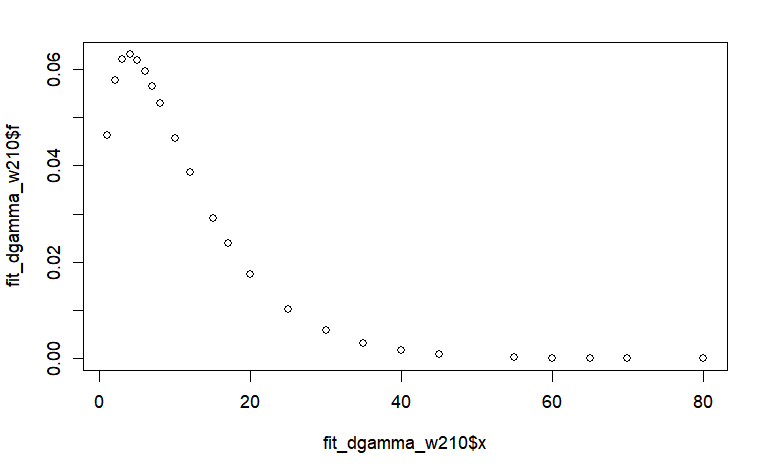

```r
plot(x= fit_dgamma_w210$x, y=fit_dgamma_w210$f)
```

```r
#Calculating weibull distribution
weibull_w2_2010_ <- fitdistrplus::fitdist(data=w_2_2010$DURATION%>% unlist() %>% as.numeric(), "weibull", method="mle", optim.method="Nelder-Mead", weights = round(w_2_2010$WGHT_EPI))
summary(weibull_w2_2010_)
```

```
Fitting of the distribution ' weibull ' by maximum likelihood
Parameters :
```

|  | estimate | Std. Error |
| --- | --- | --- |
| shape | 1.200098 | 0.000738683 |
| scale | 12.318640 | 0.009156381 |

```
Loglikelihood:  -4816354   AIC:  9632712   BIC:  9632721
Correlation matrix:
        shape   scale
shape 1.00000 0.32972
scale 0.32972 1.00000
```

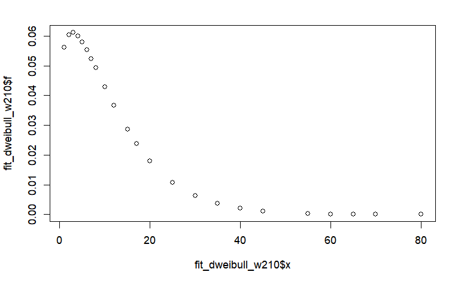

```r
fit_dweibull_w210 <- data.frame(f = dweibull(w_2_2010$DURATION, shape = weibull_w2_2010_$estimate[1], scale = weibull_w2_2010_$estimate[2]), x = w_2_2010$DURATION, type = "weibull")

plot(x= fit_dweibull_w210$x, y=fit_dweibull_w210$f)
```

```r
#Calculating exponential distribution
exp_w2_2010_ <- fitdistrplus::fitdist(data=w_2_2010$DURATION%>% unlist() %>% as.numeric(), "exp", method="mle", optim.method="Nelder-Mead", weights = round(w_2_2010$WGHT_EPI))
summary(exp_w2_2010_)
```

```
Fitting of the distribution ' exp ' by maximum likelihood
Parameters :
```

|  | estimate | Std. Error |
| --- | --- | --- |
| rate | 0.08677028 | 7.306244e-05 |

```
Loglikelihood:  -4855875   AIC:  9711751   BIC:  9711756
```

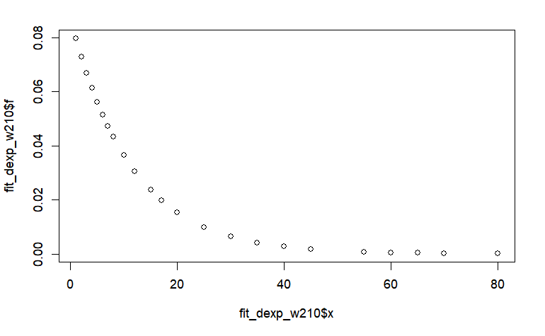

```r
fit_dexp_w210 <- data.frame(f = dexp(w_2_2010$DURATION, rate = exp_w2_2010_$estimate[1]),
                       x = w_2_2010$DURATION, type = "exp")

plot(x = fit_dexp_w210$x, y = fit_dexp_w210$f)
```

```r
#Calculating lognormal distribution
lnorm_w2_2010_ <- fitdistrplus::fitdist(data=w_2_2010$DURATION%>% unlist() %>% as.numeric(), "lnorm", method="mle", optim.method="Nelder-Mead", weights = round(w_2_2010$WGHT_EPI))
summary(lnorm_w2_2010_)
```

```
Fitting of the distribution ' lnorm ' by maximum likelihood
Parameters :
```

|  | estimate | Std. Error |
| --- | --- | --- |
| meanlog | 2.0759053 | 0.0007467444 |
| sdlog | 0.8867291 | 0.0005280675 |

```
Loglikelihood:  -4758905   AIC:  9517814   BIC:  9517823
Correlation matrix:
              meanlog         sdlog
meanlog  1.0000000000 -0.0006174825
sdlog   -0.0006174825  1.0000000000
```

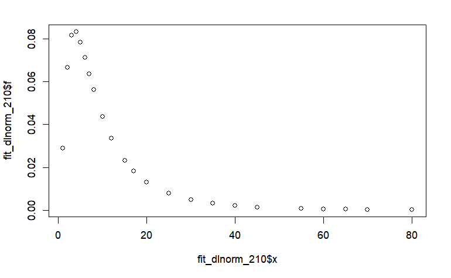

```r
fit_dlnorm_210 <- data.frame(f = dlnorm(w_2_2010$DURATION, meanlog = lnorm_w2_2010_$estimate[1], sdlog = lnorm_w2_2010_$estimate[2]), x = w_2_2010$DURATION, type = "lnorm")

plot(x= fit_dlnorm_210$x, y=fit_dlnorm_210$f)
```

Now let’s compare these models AIC and BIC to see which fits the walk data best:

```r
#comparing these models AIC and BIC to see which fits the walk data best:
broom::glance(MASS::fitdistr(w_2_2010$DURATION%>% unlist() %>% as.numeric(),"gamma"))
```

| logLik | AIC | BIC | nobs |
| --- | --- | --- | --- |
| -2243.15 | 4490.3 | 4499.269 | 655 |

```r
broom::glance(MASS::fitdistr(w_2_2010$DURATION%>% unlist() %>% as.numeric(),"weibull"))
```

| logLik | AIC | BIC | nobs |
| --- | --- | --- | --- |
| -2252.498 | 4508.996 | 4517.966 | 655 |

```r
broom::glance(MASS::fitdistr(w_2_2010$DURATION%>% unlist() %>% as.numeric(),"exponential"))
```

| logLik | AIC | BIC | nobs |
| --- | --- | --- | --- |
| -2269.313 | 4540.626 | 4545.111 | 655 |

```r
broom::glance(MASS::fitdistr(w_2_2010$DURATION%>% unlist() %>% as.numeric(),"lognormal"))
```

| logLik | AIC | BIC | nobs |
| --- | --- | --- | --- |
| -2229.515 | 4463.029 | 4471.999 | 655 |

So, lognormal has largest logLik and the smallest AIC and BIC. we will pick lognormal function for walking trips in 2010!

```r
walking_2010_lnorm <- lnorm_w2_2010_
w_2_2010 <- w_2_2010 %>%
 mutate(f_2 = dlnorm(DURATION, walking_2010_lnorm$estimate["meanlog"], walking_2010_lnorm$estimate["sdlog"]))
summary(w_2_2010$f_2)
```

```
     Min.   1st Qu.    Median      Mean   3rd Qu.      Max.
0.0001911 0.0232632 0.0435440 0.0467089 0.0783533 0.0831236
```

###Destination : other’s home (3)

using a skew vs. kurtois graph to descriptive statistics of data

```
summary statistics
------
min:  1   max:  90
median:  5
mean:  8.641129
estimated sd:  11.17936
estimated skewness:  2.980763
estimated kurtosis:  14.44213
```

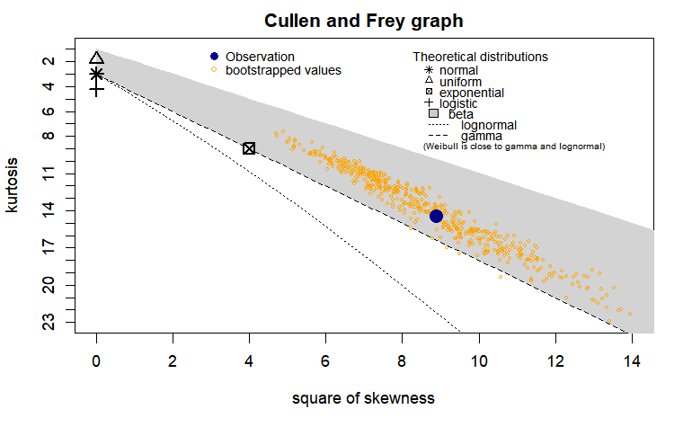

```r
# creating a skew vs. kurtois graph for walking 2010

# Filter the data based on the "destination" column
 w_3_2010 <- walking_2010 %>%
  filter(destination == "3")
descdist(w_3_2010$DURATION %>% unlist() %>% as.numeric(), discrete=FALSE, boot=500)
```

As shown in the Cullen and Frey graph, we see that gamma, weibull and exponential will likely be the best fit according to the graph above. Then we compare these models to find the best model.

```r
# Based on the skew vs. kurtois graph the best distribution

#Calculating gamma distribution
gamma_w3_2010_ <- fitdistrplus::fitdist(data=w_3_2010$DURATION%>% unlist() %>% as.numeric(), "gamma", method="mle", optim.method="Nelder-Mead", weights = round(w_3_2010$WGHT_EPI))
fit_dgamma_w310 <- data.frame(f = dgamma(w_3_2010$DURATION, shape = gamma_w3_2010_$estimate[1], rate = gamma_w3_2010_$estimate[2]), x = w_3_2010$DURATION, type = "Gamma")

summary(gamma_w3_2010_)
```

```
Fitting of the distribution ' gamma ' by maximum likelihood
Parameters :
```

|  | estimate | Std. Error |
| --- | --- | --- |
| shape | 1.0113415 | 0.0014031421 |
| rate | 0.1073175 | 0.0001904522 |

```
Loglikelihood:  -2617139   AIC:  5234282   BIC:  5234290
Correlation matrix:
          shape      rate
shape 1.0000000 0.7816741
rate  0.7816741 1.0000000
```

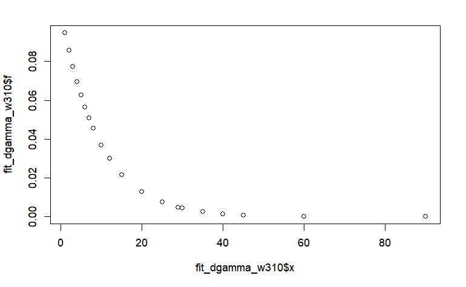

```r
plot(x= fit_dgamma_w310$x, y=fit_dgamma_w310$f)
```

```r
#Calculating weibull distribution
weibull_w3_2010_ <- fitdistrplus::fitdist(data=w_3_2010$DURATION%>% unlist() %>% as.numeric(), "weibull", method="mle", optim.method="Nelder-Mead", weights = round(w_3_2010$WGHT_EPI))
summary(weibull_w3_2010_)
```

```
Fitting of the distribution ' weibull ' by maximum likelihood
Parameters :
```

|  | estimate | Std. Error |
| --- | --- | --- |
| shape | 0.9511828 | 0.0007767165 |
| scale | 9.1812286 | 0.0113978575 |

```
Loglikelihood:  -2615236   AIC:  5230476   BIC:  5230485
Correlation matrix:
         shape    scale
shape 1.000000 0.333888
scale 0.333888 1.000000
```

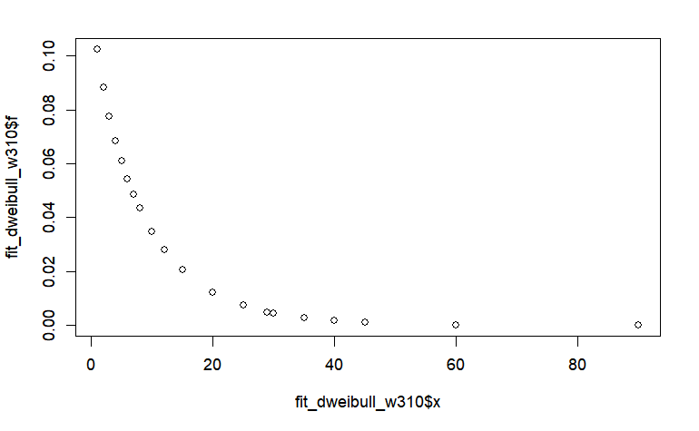

```r
fit_dweibull_w310 <- data.frame(f = dweibull(w_3_2010$DURATION, shape = weibull_w3_2010_$estimate[1], scale = weibull_w3_2010_$estimate[2]), x = w_3_2010$DURATION, type = "weibull")

plot(x= fit_dweibull_w310$x, y=fit_dweibull_w310$f)
```

```r
#Calculating exponential distribution
exp_w3_2010_ <- fitdistrplus::fitdist(data=w_3_2010$DURATION%>% unlist() %>% as.numeric(), "exp", method="mle", optim.method="Nelder-Mead", weights = round(w_3_2010$WGHT_EPI))
summary(exp_w3_2010_)
```

```
Fitting of the distribution ' exp ' by maximum likelihood
Parameters :
```

|  | estimate | Std. Error |
| --- | --- | --- |
| rate | 0.1061421 | 0.0001181456 |

```
Loglikelihood:  -2617173   AIC:  5234348   BIC:  5234352
```

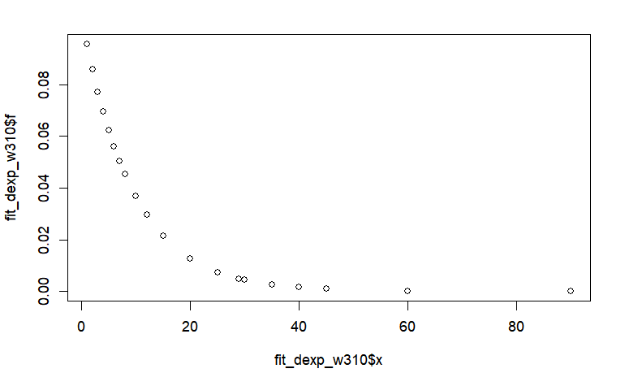

```r
fit_dexp_w310 <- data.frame(f = dexp(w_3_2010$DURATION, rate = exp_w3_2010_$estimate[1]),
                       x = w_3_2010$DURATION, type = "exp")

plot(x = fit_dexp_w310$x, y = fit_dexp_w310$f)
```

Now let’s compare these models AIC and BIC to see which fits the walk data best:

```r
#comparing these models AIC and BIC to see which fits the walk data best:
broom::glance(MASS::fitdistr(w_3_2010$DURATION%>% unlist() %>% as.numeric(),"gamma"))
```

| logLik | AIC | BIC | nobs |
| --- | --- | --- | --- |
| -1565.599 | 3135.199 | 3143.612 | 496 |

```r
broom::glance(MASS::fitdistr(w_3_2010$DURATION%>% unlist() %>% as.numeric(),"weibull"))
```

| logLik | AIC | BIC | nobs |
| --- | --- | --- | --- |
| -1563.848 | 3131.697 | 3140.11 | 496 |

```r
broom::glance(MASS::fitdistr(w_3_2010$DURATION%>% unlist() %>% as.numeric(),"exponential"))
```

| logLik | AIC | BIC | nobs |
| --- | --- | --- | --- |
| -1565.64 | 3133.281 | 3137.488 | 496 |

```r
walking_310_exp <- exp_w3_2010_
w_3_2010 <- w_3_2010 %>%
 mutate(f_3 = dexp(DURATION, walking_310_exp$estimate["rate"]))
summary(w_3_2010$f_3)
```

```
     Min.   1st Qu.    Median      Mean   3rd Qu.      Max.
7.540e-06 3.672e-02 6.243e-02 5.878e-02 8.584e-02 9.545e-02
```

###Destination : Restaurant/bar (4)

using a skew vs. kurtois graph to descriptive statistics of data

```
summary statistics
------
min:  1   max:  90
median:  5
mean:  10.80137
estimated sd:  12.62917
estimated skewness:  3.294198
estimated kurtosis:  16.42833
```

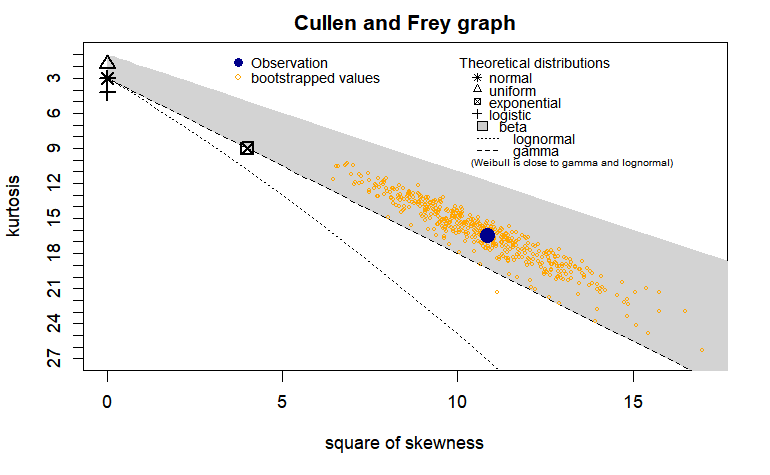

```r
# creating a skew vs. kurtois graph for walking 2010

# Filter the data based on the "destination" column
 w_4_2010 <- walking_2010 %>%
  filter(destination == "4")
descdist(w_4_2010$DURATION %>% unlist() %>% as.numeric(), discrete=FALSE, boot=500)
```

As shown in the Cullen and Frey graph, we see that gamma, weibull and exponential will likely be the best fit according to the graph above. Then we compare these models to find the best model.

```r
# Based on the skew vs. kurtois graph the best distribution

#Calculating gamma distribution
gamma_w4_2010_ <- fitdistrplus::fitdist(data=w_4_2010$DURATION%>% unlist() %>% as.numeric(), "gamma", method="mle", optim.method="Nelder-Mead", weights = round(w_4_2010$WGHT_EPI))
fit_dgamma_w410 <- data.frame(f = dgamma(w_4_2010$DURATION, shape = gamma_w4_2010_$estimate[1], rate = gamma_w4_2010_$estimate[2]), x = w_4_2010$DURATION, type = "Gamma")

summary(gamma_w4_2010_)
```

```
Fitting of the distribution ' gamma ' by maximum likelihood
Parameters :
```

|  | estimate | Std. Error |
| --- | --- | --- |
| shape | 1.3529871 | 0.0018575412 |
| rate | 0.1222511 | 0.0002023062 |

```
Loglikelihood:  -2923222   AIC:  5846448   BIC:  5846456
Correlation matrix:
          shape      rate
shape 1.0000000 0.8295454
rate  0.8295454 1.0000000
```

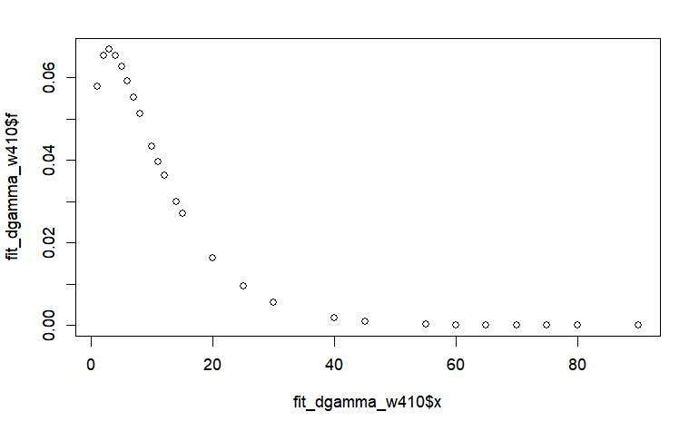

```r
plot(x= fit_dgamma_w410$x, y=fit_dgamma_w410$f)
```

```r
#Calculating weibull distribution
weibull_w4_2010_ <- fitdistrplus::fitdist(data=w_4_2010$DURATION%>% unlist() %>% as.numeric(), "weibull", method="mle", optim.method="Nelder-Mead", weights = round(w_4_2010$WGHT_EPI))
summary(weibull_w4_2010_)
```

```
Fitting of the distribution ' weibull ' by maximum likelihood
Parameters :
```

|  | estimate | Std. Error |
| --- | --- | --- |
| shape | 1.09429 | 0.0008290921 |
| scale | 11.51861 | 0.0120113084 |

```
Loglikelihood:  -2938899   AIC:  5877802   BIC:  5877810
Correlation matrix:
          shape     scale
shape 1.0000000 0.3346259
scale 0.3346259 1.0000000
```

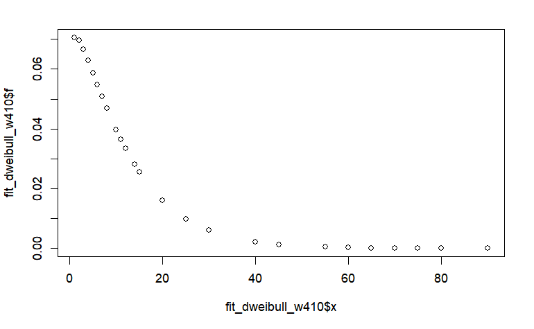

```r
fit_dweibull_w410 <- data.frame(f = dweibull(w_4_2010$DURATION, shape = weibull_w4_2010_$estimate[1], scale = weibull_w4_2010_$estimate[2]), x = w_4_2010$DURATION, type = "weibull")

plot(x= fit_dweibull_w410$x, y=fit_dweibull_w410$f)
```

```r
#Calculating exponential distribution
exp_w4_2010_ <- fitdistrplus::fitdist(data=w_4_2010$DURATION%>% unlist() %>% as.numeric(), "exp", method="mle", optim.method="Nelder-Mead", weights = round(w_4_2010$WGHT_EPI))
summary(exp_w4_2010_)
```

```
Fitting of the distribution ' exp ' by maximum likelihood
Parameters :
```

|  | estimate | Std. Error |
| --- | --- | --- |
| rate | 0.09037482 | 9.714096e-05 |

```
Loglikelihood:  -2945585   AIC:  5891171   BIC:  5891175
```

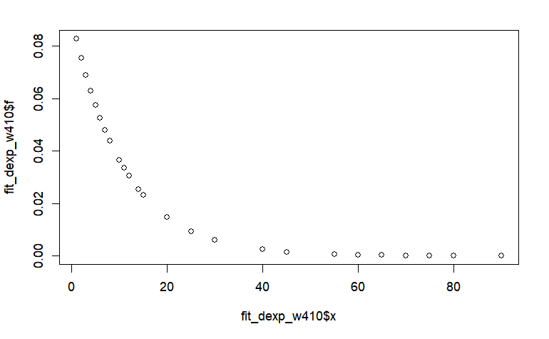

```r
fit_dexp_w410 <- data.frame(f = dexp(w_4_2010$DURATION, rate = exp_w4_2010_$estimate[1]),
                       x = w_4_2010$DURATION, type = "exp")

plot(x = fit_dexp_w410$x, y = fit_dexp_w410$f)
```

Now let’s compare these models AIC and BIC to see which fits the walk data best:

```r
#comparing these models AIC and BIC to see which fits the walk data best:
broom::glance(MASS::fitdistr(w_4_2010$DURATION%>% unlist() %>% as.numeric(),"gamma"))
```

| logLik | AIC | BIC | nobs |
| --- | --- | --- | --- |
| -1471.835 | 2947.669 | 2955.834 | 438 |

```r
broom::glance(MASS::fitdistr(w_4_2010$DURATION%>% unlist() %>% as.numeric(),"weibull"))
```

| logLik | AIC | BIC | nobs |
| --- | --- | --- | --- |
| -1478.493 | 2960.985 | 2969.149 | 438 |

```r
broom::glance(MASS::fitdistr(w_4_2010$DURATION%>% unlist() %>% as.numeric(),"exponential"))
```

| logLik | AIC | BIC | nobs |
| --- | --- | --- | --- |
| -1480.297 | 2962.594 | 2966.676 | 438 |

So, gamma has largest logLik and the smallest AIC and BIC. we will pick gamma function for walking trips in 2010!

```r
walking_410_gamma <- gamma_w4_2010_
w_4_2010 <- w_4_2010 %>%
 mutate(f_4 = dgamma(DURATION, walking_410_gamma$estimate["shape"],walking_410_gamma$estimate["rate"] ))
summary(w_4_2010$f_4)
```

```
     Min.   1st Qu.    Median      Mean   3rd Qu.      Max.
5.330e-06 4.338e-02 5.783e-02 4.716e-02 6.259e-02 6.674e-02
```

###Destination : Place of worship (5)

using a skew vs. kurtois graph to descriptive statistics of data

```
summary statistics
------
min:  1   max:  60
median:  8
mean:  10.12195
estimated sd:  9.729325
estimated skewness:  3.723922
estimated kurtosis:  20.48626
```

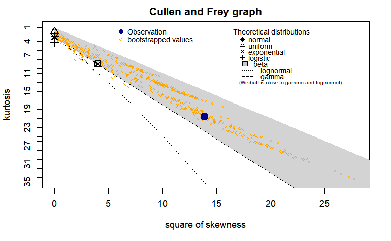

```r
# creating a skew vs. kurtois graph for walking 2010

# Filter the data based on the "destination" column
 w_5_2010 <- walking_2010 %>%
  filter(destination == "5")
descdist(w_5_2010$DURATION %>% unlist() %>% as.numeric(), discrete=FALSE, boot=500)
```

As shown in the Cullen and Frey graph, we see that gamma, weibull, normal, logistic and exponential will likely be the best fit according to the graph above. Then we compare these models to find the best model.

```r
# Based on the skew vs. kurtois graph the best distribution

#Calculating gamma distribution
gamma_w5_2010_ <- fitdistrplus::fitdist(data=w_5_2010$DURATION%>% unlist() %>% as.numeric(), "gamma", method="mle", optim.method="Nelder-Mead", weights = round(w_5_2010$WGHT_EPI))
fit_dgamma_w510 <- data.frame(f = dgamma(w_5_2010$DURATION, shape = gamma_w5_2010_$estimate[1], rate = gamma_w5_2010_$estimate[2]), x = w_5_2010$DURATION, type = "Gamma")

summary(gamma_w5_2010_)
```

```
Fitting of the distribution ' gamma ' by maximum likelihood
Parameters :
```

|  | estimate | Std. Error |
| --- | --- | --- |
| shape | 2.8590850 | 0.015648072 |
| rate | 0.3126027 | 0.001870128 |

```
Loglikelihood:  -178598.5   AIC:  357201   BIC:  357204.4
Correlation matrix:
          shape      rate
shape 1.0000000 0.9148456
rate  0.9148456 1.0000000
```

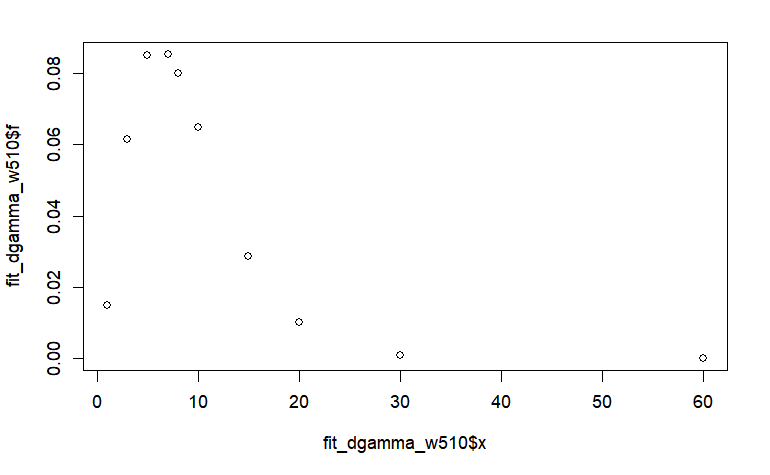

```r
plot(x= fit_dgamma_w510$x, y=fit_dgamma_w510$f)
```

```r
#Calculating weibull distribution
weibull_w5_2010_ <- fitdistrplus::fitdist(data=w_5_2010$DURATION%>% unlist() %>% as.numeric(), "weibull", method="mle", optim.method="Nelder-Mead", weights = round(w_5_2010$WGHT_EPI))
summary(weibull_w5_2010_)
```

```
Fitting of the distribution ' weibull ' by maximum likelihood
Parameters :
```

|  | estimate | Std. Error |
| --- | --- | --- |
| shape | 1.552533 | 0.004265116 |
| scale | 10.274827 | 0.028718774 |

```
Loglikelihood:  -183150.9   AIC:  366305.9   BIC:  366309.3
Correlation matrix:
          shape     scale
shape 1.0000000 0.3368671
scale 0.3368671 1.0000000
```

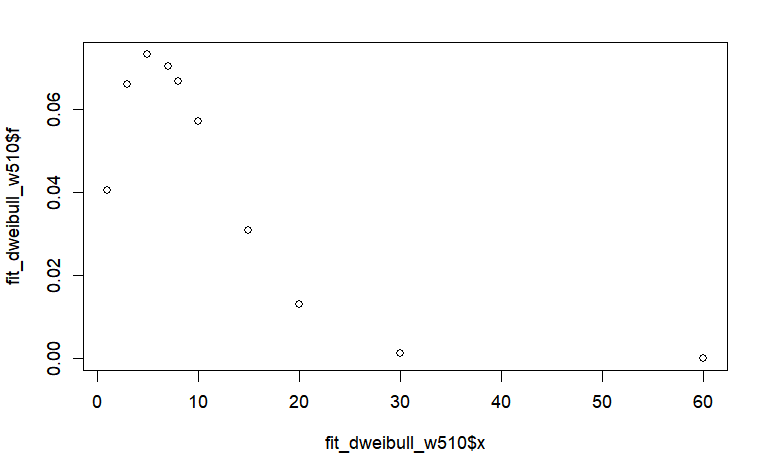

```r
fit_dweibull_w510 <- data.frame(f = dweibull(w_5_2010$DURATION, shape = weibull_w5_2010_$estimate[1], scale = weibull_w5_2010_$estimate[2]), x = w_5_2010$DURATION, type = "weibull")

plot(x= fit_dweibull_w510$x, y=fit_dweibull_w510$f)
```

```r
#Calculating exponential distribution
exp_w5_2010_ <- fitdistrplus::fitdist(data=w_5_2010$DURATION%>% unlist() %>% as.numeric(), "exp", method="mle", optim.method="Nelder-Mead", weights = round(w_5_2010$WGHT_EPI))
summary(exp_w5_2010_)
```

```
Fitting of the distribution ' exp ' by maximum likelihood
Parameters :
```

|  | estimate | Std. Error |
| --- | --- | --- |
| rate | 0.1092922 | 0.0004463954 |

```
Loglikelihood:  -192590.6   AIC:  385183.1   BIC:  385184.9
```

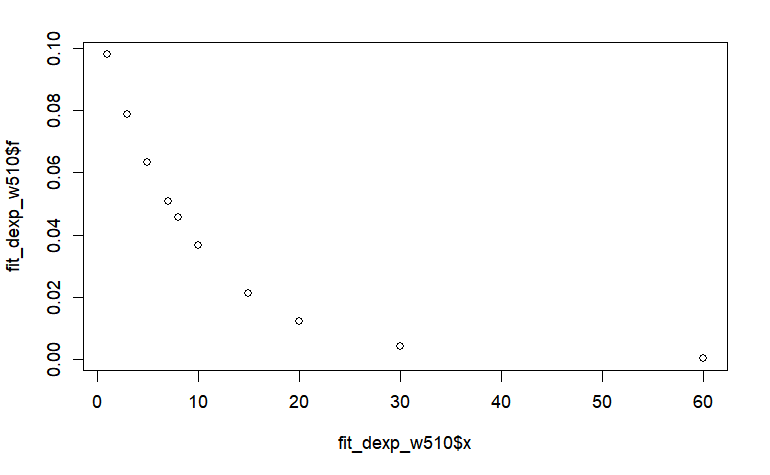

```r
fit_dexp_w510 <- data.frame(f = dexp(w_5_2010$DURATION, rate = exp_w5_2010_$estimate[1]),
                       x = w_5_2010$DURATION, type = "exp")

plot(x = fit_dexp_w510$x, y = fit_dexp_w510$f)
```

```r
#Calculating normal distribution
norm_w5_2010_ <- fitdistrplus::fitdist(data=w_5_2010$DURATION%>% unlist() %>% as.numeric(), "norm", method="mle", optim.method="Nelder-Mead", weights = round(w_5_2010$WGHT_EPI))
summary(norm_w5_2010_)
```

```
Fitting of the distribution ' norm ' by maximum likelihood
Parameters :
```

|  | estimate | Std. Error |
| --- | --- | --- |
| mean | 9.148102 | 0.02766915 |
| sd | 6.773744 | 0.01956420 |

```
Loglikelihood:  -199698   AIC:  399400   BIC:  399403.5
Correlation matrix:
             mean           sd
mean 1.0000000000 0.0002201945
sd   0.0002201945 1.0000000000
```

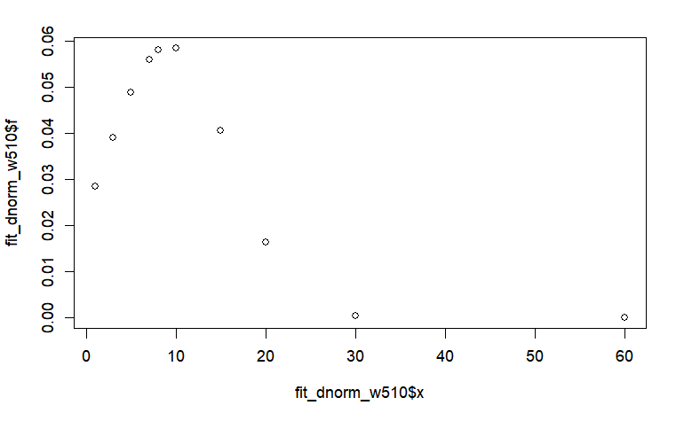

```r
fit_dnorm_w510 <- data.frame(f = dnorm(w_5_2010$DURATION, mean = norm_w5_2010_$estimate[1], sd = norm_w5_2010_$estimate[2]),
                       x = w_5_2010$DURATION, type = "norm")

plot(x = fit_dnorm_w510$x, y = fit_dnorm_w510$f)
```

```r
#Calculating logistic distribution
logis_w5_2010_ <- fitdistrplus::fitdist(data=w_5_2010$DURATION%>% unlist() %>% as.numeric(), "logis", method="mle", optim.method="Nelder-Mead", weights = round(w_5_2010$WGHT_EPI))
summary(logis_w5_2010_)
```

```
Fitting of the distribution ' logis ' by maximum likelihood
Parameters :
```

|  | estimate | Std. Error |
| --- | --- | --- |
| location | 8.108948 | 0.02064486 |
| scale | 2.988210 | 0.01041380 |

```
Loglikelihood:  -188499.2   AIC:  377002.4   BIC:  377005.8
Correlation matrix:
          location     scale
location 1.0000000 0.1047758
scale    0.1047758 1.0000000
```

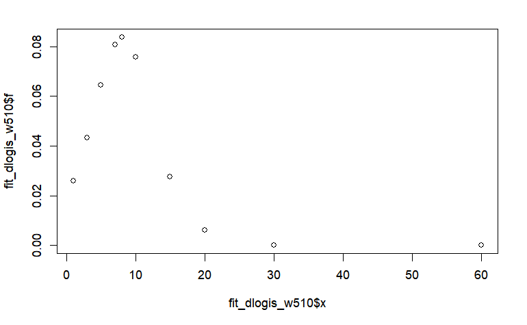

```r
fit_dlogis_w510 <- data.frame(f = dlogis(w_5_2010$DURATION, location = logis_w5_2010_$estimate[1], scale = logis_w5_2010_$estimate[2]),
                       x = w_5_2010$DURATION, type = "logis")

plot(x = fit_dlogis_w510$x, y = fit_dlogis_w510$f)
```

Now let’s compare these models AIC and BIC to see which fits the walk data best:

```r
#comparing these models AIC and BIC to see which fits the walk data best:
broom::glance(MASS::fitdistr(w_5_2010$DURATION%>% unlist() %>% as.numeric(),"gamma"))
```

| logLik | AIC | BIC | nobs |
| --- | --- | --- | --- |
| -131.3333 | 266.6666 | 270.0937 | 41 |

```r
broom::glance(MASS::fitdistr(w_5_2010$DURATION%>% unlist() %>% as.numeric(),"weibull"))
```

| logLik | AIC | BIC | nobs |
| --- | --- | --- | --- |
| -133.3862 | 270.7724 | 274.1996 | 41 |

```r
broom::glance(MASS::fitdistr(w_5_2010$DURATION%>% unlist() %>% as.numeric(),"exponential"))
```

| logLik | AIC | BIC | nobs |
| --- | --- | --- | --- |
| -135.903 | 273.8059 | 275.5195 | 41 |

```r
broom::glance(MASS::fitdistr(w_5_2010$DURATION%>% unlist() %>% as.numeric(),"normal"))
```

| logLik | AIC | BIC | nobs |
| --- | --- | --- | --- |
| -150.9512 | 305.9024 | 309.3296 | 41 |

```r
broom::glance(MASS::fitdistr(w_5_2010$DURATION%>% unlist() %>% as.numeric(),"logistic"))
```

| logLik | AIC | BIC | nobs |
| --- | --- | --- | --- |
| -139.701 | 283.4019 | 286.8291 | 41 |

So, gamma has largest logLik and the smallest AIC and BIC. we will pick gamma function for walking trips in 2010!

```r
walking_510_gamma <- gamma_w5_2010_
w_5_2010 <- w_5_2010 %>%
 mutate(f_5 = dgamma(DURATION, walking_510_gamma$estimate["shape"],walking_510_gamma$estimate["rate"] ))
summary(w_5_2010$f_5)
```

```
     Min.   1st Qu.    Median      Mean   3rd Qu.      Max.
0.0000003 0.0615990 0.0647617 0.0616772 0.0852091 0.0852368
```

###Destination :Grocery store, other stores or mall (6 ad 7)

using a skew vs. kurtois graph to descriptive statistics of data

```r
# creating a skew vs. kurtois graph for walking 2010

# Filter the data based on the "destination" column
 w_6_2010 <- walking_2010 %>%
  filter(destination %in% c("6", "7"))
descdist(w_6_2010$DURATION %>% unlist() %>% as.numeric(), discrete=FALSE, boot=500)
```

[output not shown]

```r
# Based on the skew vs. kurtois graph the best distribution

#Calculating gamma distribution
gamma_w6_2010_ <- fitdistrplus::fitdist(data=w_6_2010$DURATION%>% unlist() %>% as.numeric(), "gamma", method="mle", optim.method="Nelder-Mead", weights = round(w_6_2010$WGHT_EPI))
fit_dgamma_w610 <- data.frame(f = dgamma(w_6_2010$DURATION, shape = gamma_w6_2010_$estimate[1], rate = gamma_w6_2010_$estimate[2]), x = w_6_2010$DURATION, type = "Gamma")

summary(gamma_w6_2010_)
```

```
Fitting of the distribution ' gamma ' by maximum likelihood
Parameters :
```

|  | estimate | Std. Error |
| --- | --- | --- |
| shape | 1.2615544 | 0.0015754184 |
| rate | 0.1128301 | 0.0001720577 |

```
Loglikelihood:  -3514690   AIC:  7029383   BIC:  7029392
Correlation matrix:
          shape      rate
shape 1.0000000 0.8188114
rate  0.8188114 1.0000000
```

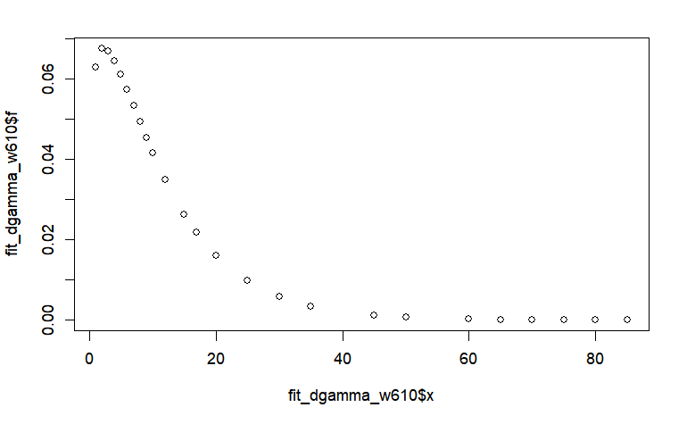

```r
plot(x= fit_dgamma_w610$x, y=fit_dgamma_w610$f)
```

```r
#Calculating weibull distribution
weibull_w6_2010_ <- fitdistrplus::fitdist(data=w_6_2010$DURATION%>% unlist() %>% as.numeric(), "weibull", method="mle", optim.method="Nelder-Mead", weights = round(w_6_2010$WGHT_EPI))
summary(weibull_w6_2010_)
```

```
Fitting of the distribution ' weibull ' by maximum likelihood
Parameters :
```

|  | estimate | Std. Error |
| --- | --- | --- |
| shape | 1.09096 | 0.0007904707 |
| scale | 11.59693 | 0.0110717603 |

```
Loglikelihood:  -3524099   AIC:  7048201   BIC:  7048210
Correlation matrix:
          shape     scale
shape 1.0000000 0.3295356
scale 0.3295356 1.0000000
```

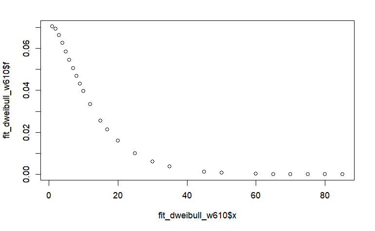

```r
fit_dweibull_w610 <- data.frame(f = dweibull(w_6_2010$DURATION, shape = weibull_w6_2010_$estimate[1], scale = weibull_w6_2010_$estimate[2]), x = w_6_2010$DURATION, type = "weibull")

plot(x= fit_dweibull_w610$x, y=fit_dweibull_w610$f)
```

```r
#Calculating exponential distribution
exp_w6_2010_ <- fitdistrplus::fitdist(data=w_6_2010$DURATION%>% unlist() %>% as.numeric(), "exp", method="mle", optim.method="Nelder-Mead", weights = round(w_6_2010$WGHT_EPI))
summary(exp_w6_2010_)
```

```
Fitting of the distribution ' exp ' by maximum likelihood
Parameters :
```

|  | estimate | Std. Error |
| --- | --- | --- |
| rate | 0.08941257 | 8.791032e-05 |

```
Loglikelihood:  -3530935   AIC:  7061871   BIC:  7061876
```

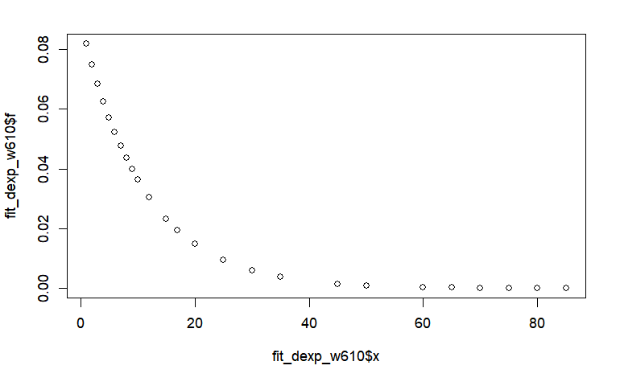

```r
fit_dexp_w610 <- data.frame(f = dexp(w_6_2010$DURATION, rate = exp_w6_2010_$estimate[1]),
                       x = w_6_2010$DURATION, type = "exp")

plot(x = fit_dexp_w610$x, y = fit_dexp_w610$f)
```

Now let’s compare these models AIC and BIC to see which fits the walk data best:

```r
#comparing these models AIC and BIC to see which fits the walk data best:
broom::glance(MASS::fitdistr(w_6_2010$DURATION%>% unlist() %>% as.numeric(),"gamma"))
```

| logLik | AIC | BIC | nobs |
| --- | --- | --- | --- |
| -1941.037 | 3886.075 | 3894.794 | 578 |

```r
broom::glance(MASS::fitdistr(w_6_2010$DURATION%>% unlist() %>% as.numeric(),"weibull"))
```

| logLik | AIC | BIC | nobs |
| --- | --- | --- | --- |
| -1946.256 | 3896.513 | 3905.232 | 578 |

```r
broom::glance(MASS::fitdistr(w_6_2010$DURATION%>% unlist() %>% as.numeric(),"exponential"))
```

| logLik | AIC | BIC | nobs |
| --- | --- | --- | --- |
| -1951.486 | 3904.971 | 3909.331 | 578 |

So, gamma has largest logLik and the smallest AIC and BIC. we will pick gamma function for walking trips in 2010!

```r
walking_610_gamma <- gamma_w6_2010_
w_6_2010 <- w_6_2010 %>%
 mutate(f_6 = dgamma(DURATION, walking_610_gamma$estimate["shape"],walking_610_gamma$estimate["rate"] ))
summary(w_6_2010$f_6)
```

```
     Min.   1st Qu.    Median      Mean   3rd Qu.      Max.
1.541e-05 2.636e-02 5.126e-02 4.490e-02 6.112e-02 6.747e-02
```

###Destination :Outdoors (9)

using a skew vs. kurtois graph to descriptive statistics of data

```
summary statistics
------
min:  1   max:  90
median:  9
mean:  10.49107
estimated sd:  10.85204
estimated skewness:  3.188484
estimated kurtosis:  18.44625
```

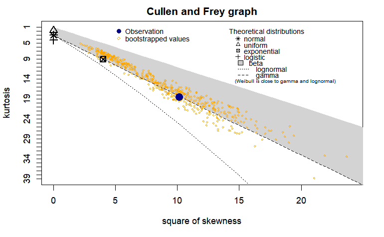

```r
# creating a skew vs. kurtois graph for walking 2010

# Filter the data based on the "destination" column
 w_9_2010 <- walking_2010 %>%
  filter(destination == "9")
descdist(w_9_2010$DURATION %>% unlist() %>% as.numeric(), discrete=FALSE, boot=500)
```

As shown in the Cullen and Frey graph, we see that gamma, weibull and exponential will likely be the best fit according to the graph above. Then we compare these models to find the best model.

```r
# Based on the skew vs. kurtois graph the best distribution

#Calculating gamma distribution
gamma_w9_2010_ <- fitdistrplus::fitdist(data=w_9_2010$DURATION%>% unlist() %>% as.numeric(), "gamma", method="mle", optim.method="Nelder-Mead", weights = round(w_9_2010$WGHT_EPI))
fit_dgamma_w910 <- data.frame(f = dgamma(w_9_2010$DURATION, shape = gamma_w9_2010_$estimate[1], rate = gamma_w9_2010_$estimate[2]), x = w_9_2010$DURATION, type = "Gamma")

summary(gamma_w9_2010_)
```

```
Fitting of the distribution ' gamma ' by maximum likelihood
Parameters :
```

|  | estimate | Std. Error |
| --- | --- | --- |
| shape | 1.4831225 | 0.0030739083 |
| rate | 0.1433282 | 0.0003524071 |

```
Loglikelihood:  -1268958   AIC:  2537920   BIC:  2537927
Correlation matrix:
          shape      rate
shape 1.0000000 0.8428797
rate  0.8428797 1.0000000
```

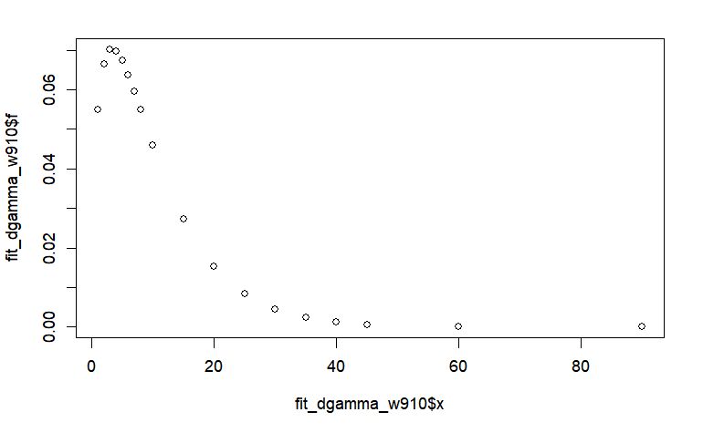

```r
plot(x= fit_dgamma_w910$x, y=fit_dgamma_w910$f)
```

```r
#Calculating exponential distribution
exp_w9_2010_ <- fitdistrplus::fitdist(data=w_9_2010$DURATION%>% unlist() %>% as.numeric(), "exp", method="mle", optim.method="Nelder-Mead", weights = round(w_9_2010$WGHT_EPI))
summary(exp_w9_2010_)
```

```
Fitting of the distribution ' exp ' by maximum likelihood
Parameters :
```

|  | estimate | Std. Error |
| --- | --- | --- |
| rate | 0.09658511 | 0.0001556148 |

```
Loglikelihood:  -1285235   AIC:  2570472   BIC:  2570476
```

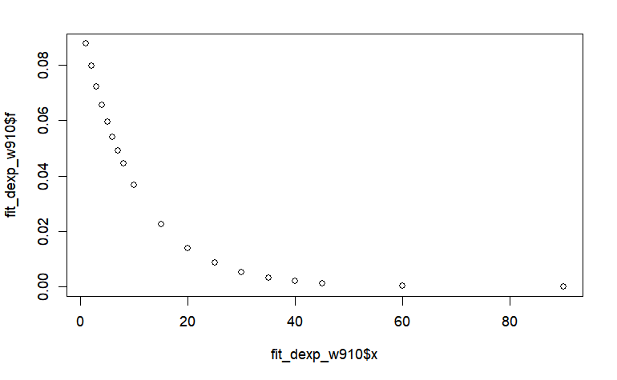

```r
fit_dexp_w910 <- data.frame(f = dexp(w_9_2010$DURATION, rate = exp_w9_2010_$estimate[1]),
                       x = w_9_2010$DURATION, type = "exp")

plot(x = fit_dexp_w910$x, y = fit_dexp_w910$f)
```

```r
#Calculating weibull distribution
weibull_w9_2010_ <- fitdistrplus::fitdist(data=w_9_2010$DURATION%>% unlist() %>% as.numeric(), "weibull", method="mle", optim.method="Nelder-Mead", weights = round(w_9_2010$WGHT_EPI))
summary(weibull_w9_2010_)
```

```
Fitting of the distribution ' weibull ' by maximum likelihood
Parameters :
```

|  | estimate | Std. Error |
| --- | --- | --- |
| shape | 1.213124 | 0.001446935 |
| scale | 11.086122 | 0.015569292 |

```
Loglikelihood:  -1273490   AIC:  2546985   BIC:  2546992
Correlation matrix:
          shape     scale
shape 1.0000000 0.3242239
scale 0.3242239 1.0000000
```

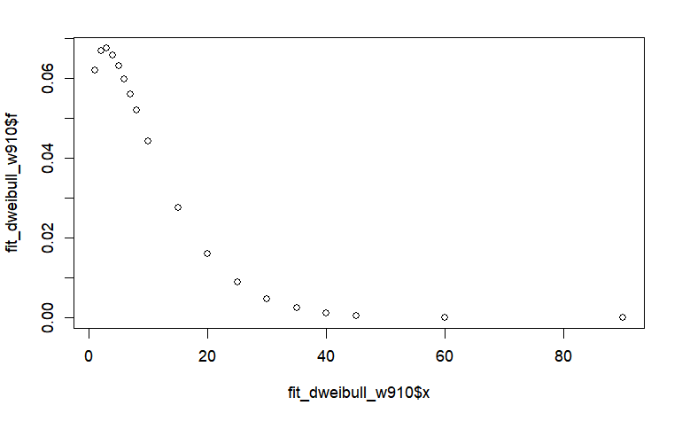

```r
fit_dweibull_w910 <- data.frame(f = dweibull(w_9_2010$DURATION, shape = weibull_w9_2010_$estimate[1], scale = weibull_w9_2010_$estimate[2]),
                       x = w_9_2010$DURATION, type = "weibull")

plot(x = fit_dweibull_w910$x, y = fit_dweibull_w910$f)
```

Now let’s compare these models AIC and BIC to see which fits the walk data best:

```r
#comparing these models AIC and BIC to see which fits the walk data best:
broom::glance(MASS::fitdistr(w_9_2010$DURATION%>% unlist() %>% as.numeric(),"gamma"))
```

| logLik | AIC | BIC | nobs |
| --- | --- | --- | --- |
| -743.9626 | 1491.925 | 1498.749 | 224 |

```r
broom::glance(MASS::fitdistr(w_9_2010$DURATION%>% unlist() %>% as.numeric(),"exponential"))
```

| logLik | AIC | BIC | nobs |
| --- | --- | --- | --- |
| -750.5175 | 1503.035 | 1506.447 | 224 |

```r
broom::glance(MASS::fitdistr(w_9_2010$DURATION%>% unlist() %>% as.numeric(),"weibull"))
```

| logLik | AIC | BIC | nobs |
| --- | --- | --- | --- |
| -747.3171 | 1498.634 | 1505.457 | 224 |

So, gamma has largest logLik and the smallest AIC and BIC. we will pick gamma function for walking trips in 2010!

```r
walking_910_gamma <- gamma_w9_2010_
w_9_2010 <- w_9_2010 %>%
 mutate(f_9 = dgamma(DURATION, walking_910_gamma$estimate["shape"], walking_910_gamma$estimate["rate"]))
summary(w_9_2010$f_9)
```

```
     Min.   1st Qu.    Median      Mean   3rd Qu.      Max.
1.390e-06 2.728e-02 5.039e-02 4.802e-02 6.728e-02 7.001e-02
```

###Destination :Library (10)

using a skew vs. kurtois graph to descriptive statistics of data

```
summary statistics
------
min:  2   max:  40
median:  10
mean:  11.34483
estimated sd:  9.001095
estimated skewness:  1.767801
estimated kurtosis:  6.644791
```

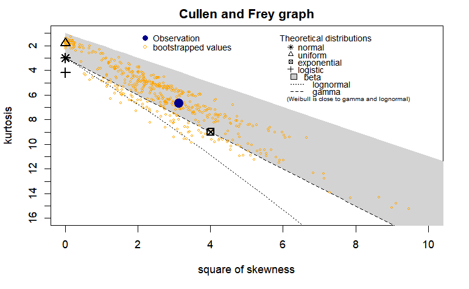

```r
# creating a skew vs. kurtois graph for walking 2010

# Filter the data based on the "destination" column
 w_10_2010 <- walking_2010 %>%
  filter(destination == "10")
descdist(w_10_2010$DURATION %>% unlist() %>% as.numeric(), discrete=FALSE, boot=500)
```

As shown in the Cullen and Frey graph, we see that gamma,weibull, normal, lognormal and exponential will likely be the best fit according to the graph above. Then we compare these models to find the best model.

```r
# Based on the skew vs. kurtois graph the best distribution

#Calculating gamma distribution
gamma_w10_2010_ <- fitdistrplus::fitdist(data=w_10_2010$DURATION%>% unlist() %>% as.numeric(), "gamma", method="mle", optim.method="Nelder-Mead", weights = round(w_10_2010$WGHT_EPI))
fit_dgamma_w1010 <- data.frame(f = dgamma(w_10_2010$DURATION, shape = gamma_w10_2010_$estimate[1], rate = gamma_w10_2010_$estimate[2]), x = w_10_2010$DURATION, type = "Gamma")

summary(gamma_w10_2010_)
```

```
Fitting of the distribution ' gamma ' by maximum likelihood
Parameters :
```

|  | estimate | Std. Error |
| --- | --- | --- |
| shape | 3.1071639 | 0.017913072 |
| rate | 0.3075958 | 0.001924537 |

```
Loglikelihood:  -165982.6   AIC:  331969.1   BIC:  331971.9
Correlation matrix:
          shape      rate
shape 1.0000000 0.9214089
rate  0.9214089 1.0000000
```

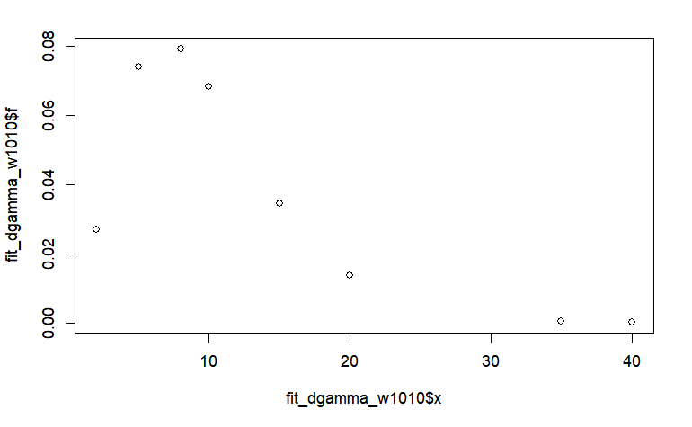

```r
plot(x= fit_dgamma_w1010$x, y=fit_dgamma_w1010$f)
```

```r
#Calculating weibull distribution
weibull_w10_2010_ <- fitdistrplus::fitdist(data=w_10_2010$DURATION%>% unlist() %>% as.numeric(), "weibull", method="mle", optim.method="Nelder-Mead", weights = round(w_10_2010$WGHT_EPI))
summary(weibull_w10_2010_)
```

```
Fitting of the distribution ' weibull ' by maximum likelihood
Parameters :
```

|  | estimate | Std. Error |
| --- | --- | --- |
| shape | 1.859957 | 0.005910919 |
| scale | 11.403946 | 0.027751470 |

```
Loglikelihood:  -166805.5   AIC:  333615   BIC:  333617.7
Correlation matrix:
          shape     scale
shape 1.0000000 0.3227304
scale 0.3227304 1.0000000
```

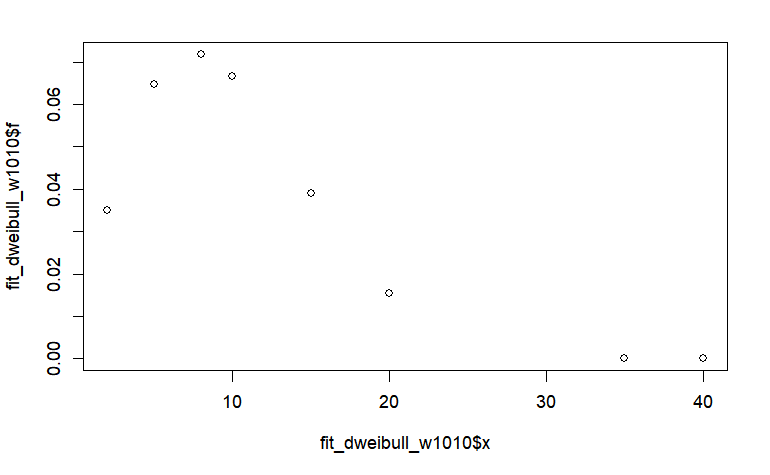

```r
fit_dweibull_w1010 <- data.frame(f = dweibull(w_10_2010$DURATION, shape = weibull_w10_2010_$estimate[1], scale = weibull_w10_2010_$estimate[2]), x = w_10_2010$DURATION, type = "weibull")

plot(x= fit_dweibull_w1010$x, y=fit_dweibull_w1010$f)
```

```r
#Calculating exponential distribution
exp_w10_2010_ <- fitdistrplus::fitdist(data=w_10_2010$DURATION%>% unlist() %>% as.numeric(), "exp", method="mle", optim.method="Nelder-Mead", weights = round(w_10_2010$WGHT_EPI))
summary(exp_w10_2010_)
```

```
Fitting of the distribution ' exp ' by maximum likelihood
Parameters :
```

|  | estimate | Std. Error |
| --- | --- | --- |
| rate | 0.09899197 | 0.0004242136 |

```
Loglikelihood:  -180359.9   AIC:  360721.8   BIC:  360723.1
```

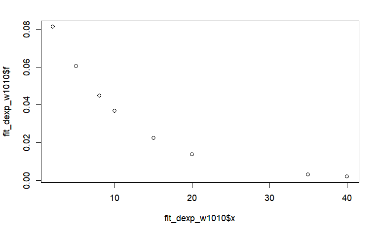

```r
fit_dexp_w1010 <- data.frame(f = dexp(w_10_2010$DURATION, rate = exp_w10_2010_$estimate[1]),
                       x = w_10_2010$DURATION, type = "exp")

plot(x = fit_dexp_w1010$x, y = fit_dexp_w1010$f)
```

```r
#Calculating normal distribution
norm_w10_2010_ <- fitdistrplus::fitdist(data=w_10_2010$DURATION%>% unlist() %>% as.numeric(), "norm", method="mle", optim.method="Nelder-Mead", weights = round(w_10_2010$WGHT_EPI))
summary(norm_w10_2010_)
```

```
Fitting of the distribution ' norm ' by maximum likelihood
Parameters :
```

|  | estimate | Std. Error |
| --- | --- | --- |
| mean | 10.103735 | 0.02460052 |
| sd | 5.740045 | 0.01739785 |

```
Loglikelihood:  -172383.1   AIC:  344770.1   BIC:  344772.9
Correlation matrix:
             mean           sd
mean 1.0000000000 0.0002111721
sd   0.0002111721 1.0000000000
```

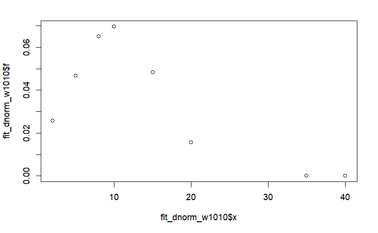

```r
fit_dnorm_w1010 <- data.frame(f = dnorm(w_10_2010$DURATION, mean = norm_w10_2010_$estimate[1], sd = norm_w10_2010_$estimate[2]),
                       x = w_10_2010$DURATION, type = "norm")

plot(x = fit_dnorm_w1010$x, y = fit_dnorm_w1010$f)
```

```r
#Calculating lognormal distribution
lnorm_w10_2010_ <- fitdistrplus::fitdist(data=w_10_2010$DURATION%>% unlist() %>% as.numeric(), "lnorm", method="mle", optim.method="Nelder-Mead", weights = round(w_10_2010$WGHT_EPI))
summary(lnorm_w10_2010_)
```

```
Fitting of the distribution ' lnorm ' by maximum likelihood
Parameters :
```

|  | estimate | Std. Error |
| --- | --- | --- |
| meanlog | 2.1432645 | 0.002635458 |
| sdlog | 0.6149321 | 0.001863340 |

```
Loglikelihood:  -167472.7   AIC:  334949.3   BIC:  334952
Correlation matrix:
              meanlog         sdlog
meanlog  1.0000000000 -0.0001909993
sdlog   -0.0001909993  1.0000000000
```

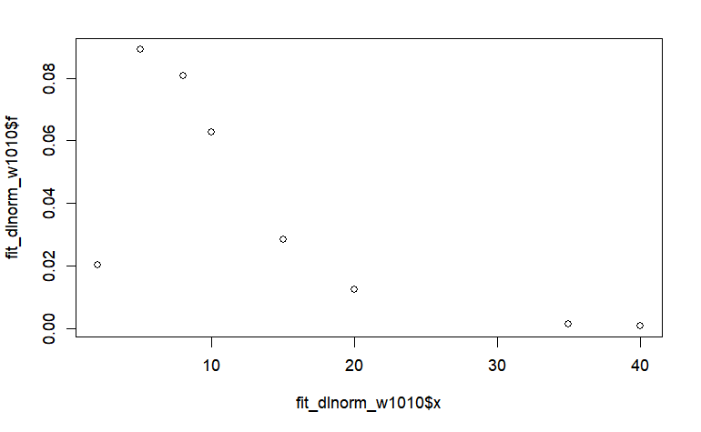

```r
fit_dlnorm_w1010 <- data.frame(f = dlnorm(w_10_2010$DURATION, meanlog = lnorm_w10_2010_$estimate[1], sdlog = lnorm_w10_2010_$estimate[2]),
                       x = w_10_2010$DURATION, type = "lnorm")

plot(x = fit_dlnorm_w1010$x, y = fit_dlnorm_w1010$f)
```

Now let’s compare these models AIC and BIC to see which fits the walk data best:

```r
#comparing these models AIC and BIC to see which fits the walk data best:
broom::glance(MASS::fitdistr(w_10_2010$DURATION%>% unlist() %>% as.numeric(),"gamma"))
```

| logLik | AIC | BIC | nobs |
| --- | --- | --- | --- |
| -96.30988 | 196.6198 | 199.3543 | 29 |

```r
broom::glance(MASS::fitdistr(w_10_2010$DURATION%>% unlist() %>% as.numeric(),"weibull"))
```

| logLik | AIC | BIC | nobs |
| --- | --- | --- | --- |
| -96.98658 | 197.9732 | 200.7077 | 29 |

```r
broom::glance(MASS::fitdistr(w_10_2010$DURATION%>% unlist() %>% as.numeric(),"exponential"))
```

| logLik | AIC | BIC | nobs |
| --- | --- | --- | --- |
| -99.4341 | 200.8682 | 202.2355 | 29 |

```r
broom::glance(MASS::fitdistr(w_10_2010$DURATION%>% unlist() %>% as.numeric(),"normal"))
```

| logLik | AIC | BIC | nobs |
| --- | --- | --- | --- |
| -104.3634 | 212.7269 | 215.4615 | 29 |

```r
broom::glance(MASS::fitdistr(w_10_2010$DURATION%>% unlist() %>% as.numeric(),"lognormal"))
```

| logLik | AIC | BIC | nobs |
| --- | --- | --- | --- |
| -95.81521 | 195.6304 | 198.365 | 29 |

```r
walking_1010_gamma <- gamma_w10_2010_
w_10_2010 <- w_10_2010 %>%
 mutate(f_10 = dgamma(DURATION, walking_1010_gamma$estimate["shape"], walking_1010_gamma$estimate["rate"]))
summary(w_10_2010$f_10)
```

```
     Min.   1st Qu.    Median      Mean   3rd Qu.      Max.
0.0001249 0.0345567 0.0684566 0.0495785 0.0739659 0.0791378
```

### Calculating impedance function for cycling in 2010

```r
count <- sum(cycling_2010$DURATION > 100)
print (count)
```

```
[1] 4
```

```r
cycling_2010 <- cycling_2010 %>% filter(DURATION < 100)
summary(cycling_2010$DURATION)
```

```
   Min. 1st Qu.  Median    Mean 3rd Qu.    Max.
   1.00   10.00   15.00   18.79   25.00   85.00
```

using a skew vs. kurtois graph to descriptive statistics of data:

```
summary statistics
------
min:  1   max:  85
median:  15
mean:  18.78505
estimated sd:  15.59194
estimated skewness:  1.82305
estimated kurtosis:  6.626848
```

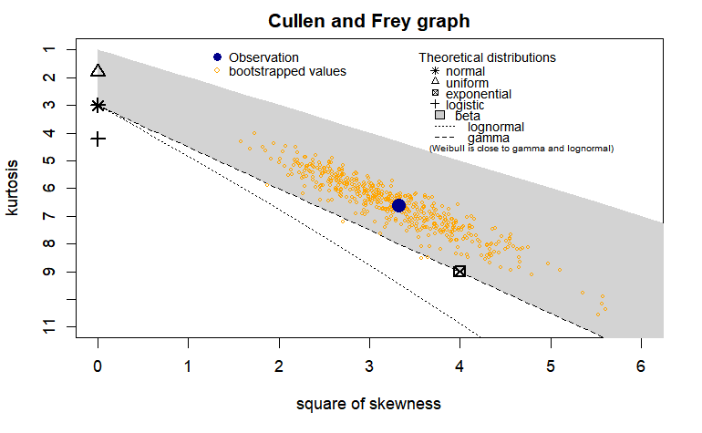

```r
# creating a skew vs. kurtois graph for cycling 2010

descdist(cycling_2010$DURATION %>% unlist() %>% as.numeric(), discrete=FALSE, boot=500)
```

As shown in the Cullen and Frey graph, we see that gamma and exponential will likely be the best fit according to the graph above. Then we compare these models to find the best model.

```r
summary(cycling_2010$DURATION)
```

```
   Min. 1st Qu.  Median    Mean 3rd Qu.    Max.
   1.00   10.00   15.00   18.79   25.00   85.00
```

```r
# Based on the skew vs. kurtois graph the best distribution

#Calculating gamma distribution

gamma_c_2010_ <- fitdistrplus::fitdist(data=cycling_2010$DURATION%>% unlist() %>% as.numeric(), "gamma", method="mle", optim.method="Nelder-Mead", weights = round(cycling_2010$WGHT_EPI))
fit_dgamma <- data.frame(f = dgamma(cycling_2010$DURATION, shape = gamma_c_2010_$estimate[1], rate = gamma_c_2010_$estimate[2]), x = cycling_2010$DURATION, type = "gamma")

summary(gamma_c_2010_)
```

```
Fitting of the distribution ' gamma ' by maximum likelihood
Parameters :
```

|  | estimate | Std. Error |
| --- | --- | --- |
| shape | 1.7517806 | 0.003035172 |
| rate | 0.1010477 | 0.000202404 |

```
Loglikelihood:  -2129485   AIC:  4258973   BIC:  4258980
Correlation matrix:
          shape      rate
shape 1.0000000 0.8648489
rate  0.8648489 1.0000000
```

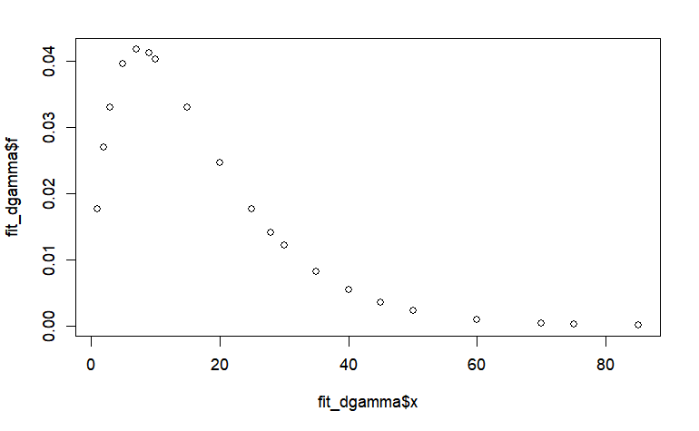

```r
plot(x= fit_dgamma$x, y=fit_dgamma$f)
```

```r
#Calculating lognormal distribution
exp_c_2010_ <- fitdistrplus::fitdist(data=cycling_2010$DURATION%>% unlist() %>% as.numeric(), "exp", method="mle", optim.method="Nelder-Mead", weights = round(cycling_2010$WGHT_EPI))
summary(exp_c_2010_)
```

```
Fitting of the distribution ' exp ' by maximum likelihood
Parameters :
```

|  | estimate | Std. Error |
| --- | --- | --- |
| rate | 0.05768385 | 7.675914e-05 |

```
Loglikelihood:  -2174564   AIC:  4349130   BIC:  4349134
```

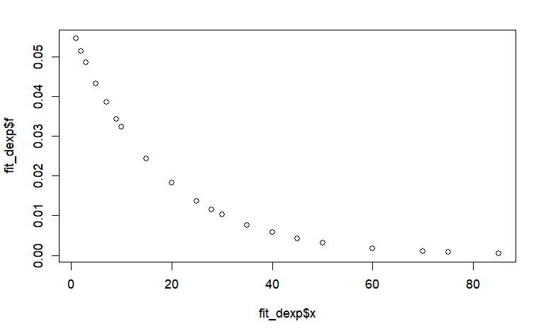

```r
fit_dexp <- data.frame(f = dexp(cycling_2010$DURATION, rate = exp_c_2010_$estimate[1]), x = cycling_2010$DURATION, type = "exp")

plot(x= fit_dexp$x, y=fit_dexp$f)
```

Now let’s compare these models based on AIC and BIC to see which fits the walk data best:

```r
#comparing these models AIC and BIC to see which fits the walk data best:
broom::glance(MASS::fitdistr(cycling_2010$DURATION%>% unlist() %>% as.numeric(),"gamma"))
```

| logLik | AIC | BIC | nobs |
| --- | --- | --- | --- |
| -823.2757 | 1650.551 | 1657.283 | 214 |

```r
broom::glance(MASS::fitdistr(cycling_2010$DURATION%>% unlist() %>% as.numeric(),"exponential"))
```

| logLik | AIC | BIC | nobs |
| --- | --- | --- | --- |
| -841.6751 | 1685.35 | 1688.716 | 214 |

```r
NA
```

So, gamma has largest logLik and the smallest AIC and BIC. we will pick gamma function for cycling trips in 2010!

```r
cycling_2010_gamma <- gamma_c_2010_
cycling_2010 <- cycling_2010 %>%
 mutate(f = dgamma(DURATION, cycling_2010_gamma$estimate["shape"], cycling_2010_gamma$estimate["rate"]))
summary(cycling_2010$f)
```

```
    Min.  1st Qu.   Median     Mean  3rd Qu.     Max.
0.000103 0.017638 0.033000 0.028332 0.040164 0.041759
```

###Destination : Cycling - Home (1), 2010

using a skew vs. kurtois graph to descriptive statistics of data

```
summary statistics
------
min:  1   max:  75
median:  15
mean:  19.40909
estimated sd:  16.48313
estimated skewness:  1.685863
estimated kurtosis:  5.553522
```

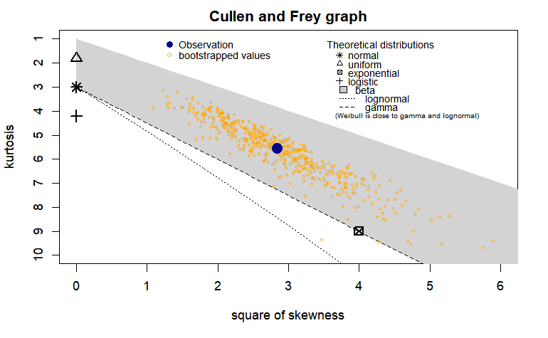

```r
# creating a skew vs. kurtois graph for cycling 2010

# Filter the data based on the "destination" column
 c_1_2010 <- cycling_2010 %>%
  filter(destination == "1")
descdist(c_1_2010$DURATION %>% unlist() %>% as.numeric(), discrete=FALSE, boot=500)
```

As shown in the Cullen and Frey graph, we see that gamma and exponential will likely be the best fit according to the graph above. Then we compare these models to find the best model.

```r
# Based on the skew vs. kurtois graph the best distribution

#Calculating gamma distribution
gamma_c1_2010_ <- fitdistrplus::fitdist(data=c_1_2010$DURATION%>% unlist() %>% as.numeric(), "gamma", method="mle", optim.method="Nelder-Mead", weights = round(c_1_2010$WGHT_EPI))
fit_dgamma_c110 <- data.frame(f = dgamma( c_1_2010$DURATION, shape = gamma_c1_2010_$estimate[1], rate = gamma_c1_2010_$estimate[2]), x = c_1_2010$DURATION, type = "Gamma")

summary(gamma_c1_2010_)
```

```
Fitting of the distribution ' gamma ' by maximum likelihood
Parameters :
```

|  | estimate | Std. Error |
| --- | --- | --- |
| shape | 1.63436789 | 0.0039844928 |
| rate | 0.09121656 | 0.0002597374 |

```
Loglikelihood:  -1079037   AIC:  2158077   BIC:  2158083
Correlation matrix:
          shape      rate
shape 1.0000000 0.8560032
rate  0.8560032 1.0000000
```

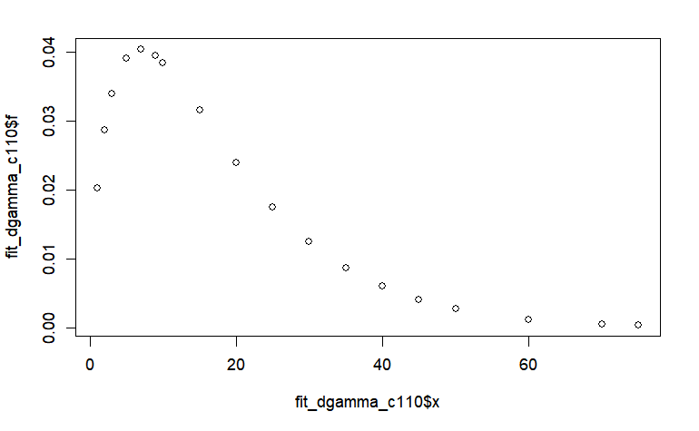

```r
plot(x= fit_dgamma_c110$x, y=fit_dgamma_c110$f)
```

```r
#Calculating exponential distribution
exp_c1_2010_ <- fitdistrplus::fitdist(data=c_1_2010$DURATION%>% unlist() %>% as.numeric(), "exp", method="mle", optim.method="Nelder-Mead", weights = round(c_1_2010$WGHT_EPI))
summary(exp_c1_2010_)
```

```
Fitting of the distribution ' exp ' by maximum likelihood
Parameters :
```

|  | estimate | Std. Error |
| --- | --- | --- |
| rate | 0.05582919 | 0.0001050451 |

```
Loglikelihood:  -1096860   AIC:  2193722   BIC:  2193724
```

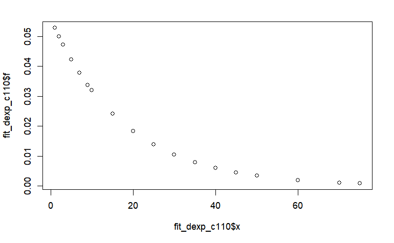

```r
fit_dexp_c110 <- data.frame(f = dexp(c_1_2010$DURATION, rate = exp_c1_2010_$estimate[1]),
                       x = c_1_2010$DURATION, type = "exp")

plot(x = fit_dexp_c110$x, y = fit_dexp_c110$f)
```

Now let’s compare these models AIC and BIC to see which fits the walk data best:

```r
#comparing these models AIC and BIC to see which fits the walk data best:
broom::glance(MASS::fitdistr(c_1_2010$DURATION%>% unlist() %>% as.numeric(),"gamma"))
```

| logLik | AIC | BIC | nobs |
| --- | --- | --- | --- |
| -428.1577 | 860.3153 | 865.7163 | 110 |

```r
broom::glance(MASS::fitdistr(c_1_2010$DURATION%>% unlist() %>% as.numeric(),"exponential"))
```

| logLik | AIC | BIC | nobs |
| --- | --- | --- | --- |
| -436.2316 | 874.4631 | 877.1636 | 110 |

So, gamma has largest logLik and the smallest AIC and BIC. we will pick gamma function for cycling trips in 2010!

```r
cycling_110_gamma <- gamma_c1_2010_
c_1_2010 <- c_1_2010 %>%
 mutate(f_1 = dgamma(DURATION, cycling_110_gamma$estimate["shape"], cycling_110_gamma$estimate["rate"]))
summary(c_1_2010$f_1)
```

```
     Min.   1st Qu.    Median      Mean   3rd Qu.      Max.
0.0003677 0.0175232 0.0315521 0.0272476 0.0384942 0.0403623
```

###Destination : Cycling - work or school (2 and 8), 2010

using a skew vs. kurtois graph to descriptive statistics of data

```
summary statistics
------
min:  1   max:  85
median:  15
mean:  21.01818
estimated sd:  15.52595
estimated skewness:  1.800378
estimated kurtosis:  7.598478
```

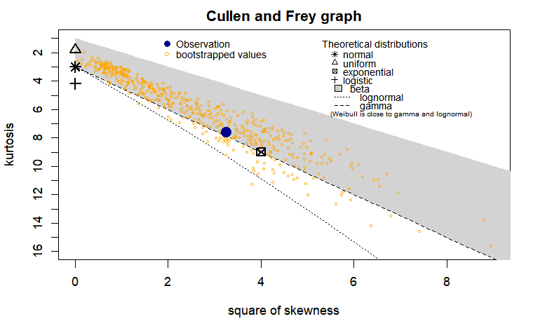

```r
# creating a skew vs. kurtois graph for cycling 2010

# Filter the data based on the "destination" column
 c_2_2010 <- cycling_2010 %>%
  filter(destination %in% c("2", "8"))
descdist(c_2_2010$DURATION %>% unlist() %>% as.numeric(), discrete=FALSE, boot=500)
```

As shown in the Cullen and Frey graph, we see that gamma, weibull, lognormal and exponential will likely be the best fit according to the graph above. Then we compare these models to find the best model.

```r
# Based on the skew vs. kurtois graph the best distribution

#Calculating gamma distribution
gamma_c2_2010_ <- fitdistrplus::fitdist(data=c_2_2010$DURATION%>% unlist() %>% as.numeric(), "gamma", method="mle", optim.method="Nelder-Mead", weights = round(c_2_2010$WGHT_EPI))
fit_dgamma_c210 <- data.frame(f = dgamma(c_2_2010$DURATION, shape = gamma_c2_2010_$estimate[1], rate = gamma_c2_2010_$estimate[2]), x = c_2_2010$DURATION, type = "Gamma")

summary(gamma_c2_2010_)
```

```
Fitting of the distribution ' gamma ' by maximum likelihood
Parameters :
```

|  | estimate | Std. Error |
| --- | --- | --- |
| shape | 1.77706259 | 0.0055905049 |
| rate | 0.09749336 | 0.0003538532 |

```
Loglikelihood:  -655137.3   AIC:  1310279   BIC:  1310283
Correlation matrix:
          shape      rate
shape 1.0000000 0.8666107
rate  0.8666107 1.0000000
```

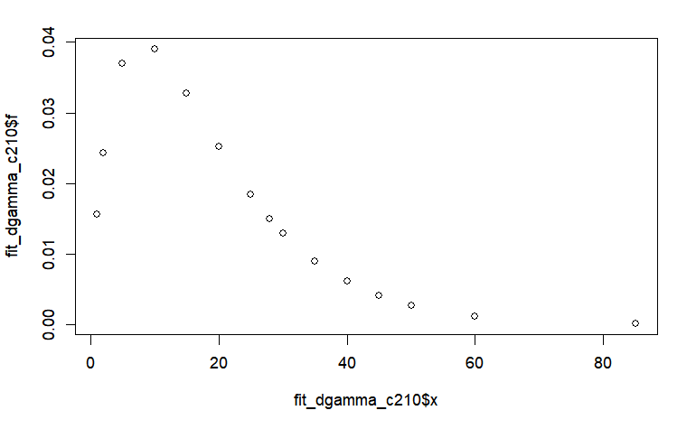

```r
plot(x= fit_dgamma_c210$x, y=fit_dgamma_c210$f)
```

```r
#Calculating weibull distribution
weibull_c2_2010_ <- fitdistrplus::fitdist(data=c_2_2010$DURATION%>% unlist() %>% as.numeric(), "weibull", method="mle", optim.method="Nelder-Mead", weights = round(c_2_2010$WGHT_EPI))
summary(weibull_c2_2010_)
```

```
Fitting of the distribution ' weibull ' by maximum likelihood
Parameters :
```

|  | estimate | Std. Error |
| --- | --- | --- |
| shape | 1.317357 | 0.002330529 |
| scale | 19.925582 | 0.038686778 |

```
Loglikelihood:  -659059.5   AIC:  1318123   BIC:  1318127
Correlation matrix:
          shape     scale
shape 1.0000000 0.3303225
scale 0.3303225 1.0000000
```

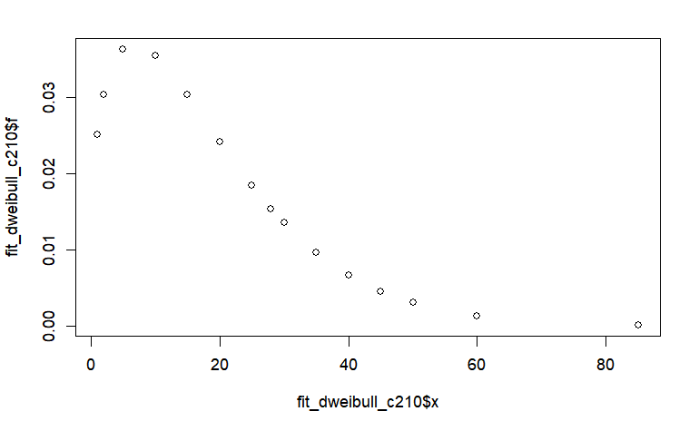

```r
fit_dweibull_c210 <- data.frame(f = dweibull(c_2_2010$DURATION, shape = weibull_c2_2010_$estimate[1], scale = weibull_c2_2010_$estimate[2]), x = c_2_2010$DURATION, type = "weibull")

plot(x= fit_dweibull_c210$x, y=fit_dweibull_c210$f)
```

```r
#Calculating exponential distribution
exp_c2_2010_ <- fitdistrplus::fitdist(data=c_2_2010$DURATION%>% unlist() %>% as.numeric(), "exp", method="mle", optim.method="Nelder-Mead", weights = round(c_2_2010$WGHT_EPI))
summary(exp_c2_2010_)
```

```
Fitting of the distribution ' exp ' by maximum likelihood
Parameters :
```

|  | estimate | Std. Error |
| --- | --- | --- |
| rate | 0.05486321 | 0.0001324248 |

```
Loglikelihood:  -669456.3   AIC:  1338915   BIC:  1338917
```

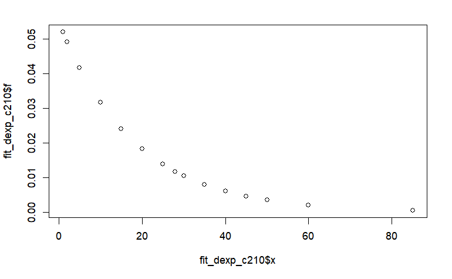

```r
fit_dexp_c210 <- data.frame(f = dexp(c_2_2010$DURATION, rate = exp_c2_2010_$estimate[1]),
                       x = c_2_2010$DURATION, type = "exp")

plot(x = fit_dexp_c210$x, y = fit_dexp_c210$f)
```

```r
#Calculating lognormal distribution
lnorm_c2_2010_ <- fitdistrplus::fitdist(data=c_2_2010$DURATION%>% unlist() %>% as.numeric(), "lnorm", method="mle", optim.method="Nelder-Mead", weights = round(c_2_2010$WGHT_EPI))
summary(lnorm_c2_2010_)
```

```
Fitting of the distribution ' lnorm ' by maximum likelihood
Parameters :
```

|  | estimate | Std. Error |
| --- | --- | --- |
| meanlog | 2.5959217 | 0.001965290 |
| sdlog | 0.8139431 | 0.001389916 |

```
Loglikelihood:  -653309   AIC:  1306622   BIC:  1306626
Correlation matrix:
             meanlog        sdlog
meanlog 1.0000000000 0.0001954368
sdlog   0.0001954368 1.0000000000
```

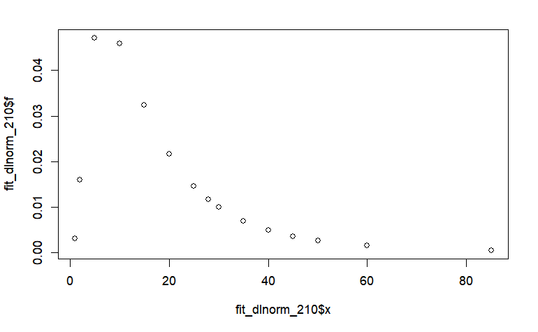

```r
fit_dlnorm_210 <- data.frame(f = dlnorm(c_2_2010$DURATION, meanlog = lnorm_c2_2010_$estimate[1], sdlog = lnorm_c2_2010_$estimate[2]), x = c_2_2010$DURATION, type = "lnorm")

plot(x= fit_dlnorm_210$x, y=fit_dlnorm_210$f)
```

Now let’s compare these models AIC and BIC to see which fits the walk data best:

```r
#comparing these models AIC and BIC to see which fits the walk data best:
broom::glance(MASS::fitdistr(c_2_2010$DURATION%>% unlist() %>% as.numeric(),"gamma"))
```

| logLik | AIC | BIC | nobs |
| --- | --- | --- | --- |
| -215.8628 | 435.7256 | 439.7402 | 55 |

```r
broom::glance(MASS::fitdistr(c_2_2010$DURATION%>% unlist() %>% as.numeric(),"weibull"))
```

| logLik | AIC | BIC | nobs |
| --- | --- | --- | --- |
| -216.6699 | 437.3397 | 441.3544 | 55 |

```r
broom::glance(MASS::fitdistr(c_2_2010$DURATION%>% unlist() %>% as.numeric(),"exponential"))
```

| logLik | AIC | BIC | nobs |
| --- | --- | --- | --- |
| -222.4963 | 446.9927 | 449 | 55 |

```r
broom::glance(MASS::fitdistr(c_2_2010$DURATION%>% unlist() %>% as.numeric(),"lognormal"))
```

| logLik | AIC | BIC | nobs |
| --- | --- | --- | --- |
| -218.1963 | 440.3925 | 444.4072 | 55 |

So, gamma has largest logLik and the smallest AIC and BIC. we will pick gamma function for cycling trips in 2010!

```r
cycling_2010_gamma <- gamma_c2_2010_
c_2_2010 <- c_2_2010 %>%
 mutate(f_2 = dgamma(DURATION, cycling_2010_gamma$estimate["shape"], cycling_2010_gamma$estimate["rate"]))
summary(c_2_2010$f_2)
```

```
     Min.   1st Qu.    Median      Mean   3rd Qu.      Max.
0.0001372 0.0130185 0.0251847 0.0253674 0.0370178 0.0389606
```

###Destination : Cycling - other’s home (3), 2010

using a skew vs. kurtois graph to descriptive statistics of data

```
summary statistics
------
min:  5   max:  45
median:  10
mean:  14.63636
estimated sd:  11.4665
estimated skewness:  1.259514
estimated kurtosis:  3.955312
```

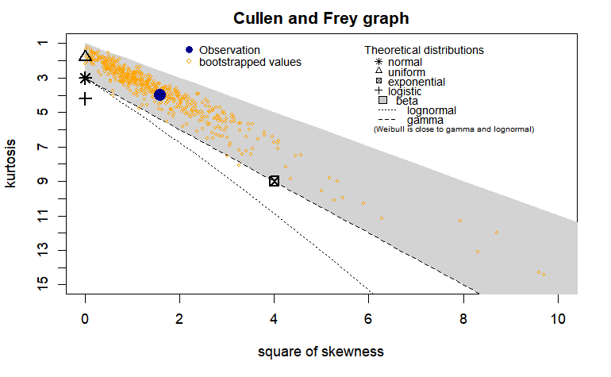

```r
# creating a skew vs. kurtois graph for cycling 2010

# Filter the data based on the "destination" column
 c_3_2010 <- cycling_2010 %>%
  filter(destination == "3")
descdist(c_3_2010$DURATION %>% unlist() %>% as.numeric(), discrete=FALSE, boot=500)
```

```r
# Based on the skew vs. kurtois graph the best distribution

#Calculating gamma distribution
gamma_c3_2010_ <- fitdistrplus::fitdist(data=c_3_2010$DURATION%>% unlist() %>% as.numeric(), "gamma", method="mle", optim.method="Nelder-Mead", weights = round(c_3_2010$WGHT_EPI))
fit_dgamma_c310 <- data.frame(f = dgamma(c_3_2010$DURATION, shape = gamma_c3_2010_$estimate[1], rate = gamma_c3_2010_$estimate[2]), x = c_3_2010$DURATION, type = "Gamma")

summary(gamma_c3_2010_)
```

```
Fitting of the distribution ' gamma ' by maximum likelihood
Parameters :
```

|  | estimate | Std. Error |
| --- | --- | --- |
| shape | 2.3283870 | 0.01274797 |
| rate | 0.1826648 | 0.00111563 |

```
Loglikelihood:  -198205.1   AIC:  396414.2   BIC:  396416.4
Correlation matrix:
          shape      rate
shape 1.0000000 0.8963941
rate  0.8963941 1.0000000
```

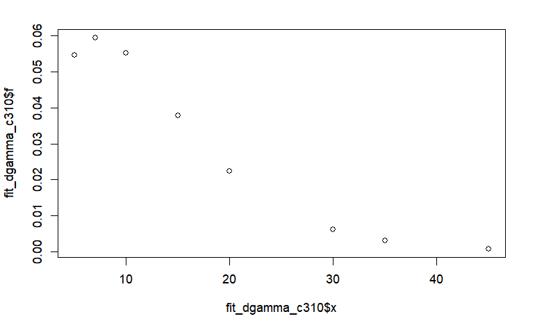

```r
plot(x= fit_dgamma_c310$x, y=fit_dgamma_c310$f)
```

```r
#Calculating weibull distribution
weibull_c3_2010_ <- fitdistrplus::fitdist(data=c_3_2010$DURATION%>% unlist() %>% as.numeric(), "weibull", method="mle", optim.method="Nelder-Mead", weights = round(c_3_2010$WGHT_EPI))
summary(weibull_c3_2010_)
```

```
Fitting of the distribution ' weibull ' by maximum likelihood
Parameters :
```

|  | estimate | Std. Error |
| --- | --- | --- |
| shape | 1.519084 | 0.004671801 |
| scale | 14.272742 | 0.041210120 |

```
Loglikelihood:  -200293   AIC:  400589.9   BIC:  400592.1
Correlation matrix:
          shape     scale
shape 1.0000000 0.3356327
scale 0.3356327 1.0000000
```

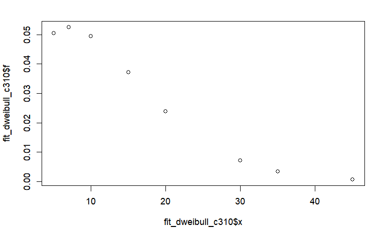

```r
fit_dweibull_c310 <- data.frame(f = dweibull(c_3_2010$DURATION, shape = weibull_c3_2010_$estimate[1], scale = weibull_c3_2010_$estimate[2]), x = c_3_2010$DURATION, type = "weibull")

plot(x= fit_dweibull_c310$x, y=fit_dweibull_c310$f)
```

```r
#Calculating exponential distribution
exp_c3_2010_ <- fitdistrplus::fitdist(data=c_3_2010$DURATION%>% unlist() %>% as.numeric(), "exp", method="mle", optim.method="Nelder-Mead", weights = round(c_3_2010$WGHT_EPI))
summary(exp_c3_2010_)
```

```
Fitting of the distribution ' exp ' by maximum likelihood
Parameters :
```

|  | estimate | Std. Error |
| --- | --- | --- |
| rate | 0.07846467 | 0.0003240902 |

```
Loglikelihood:  -207737.5   AIC:  415477   BIC:  415478.1
```

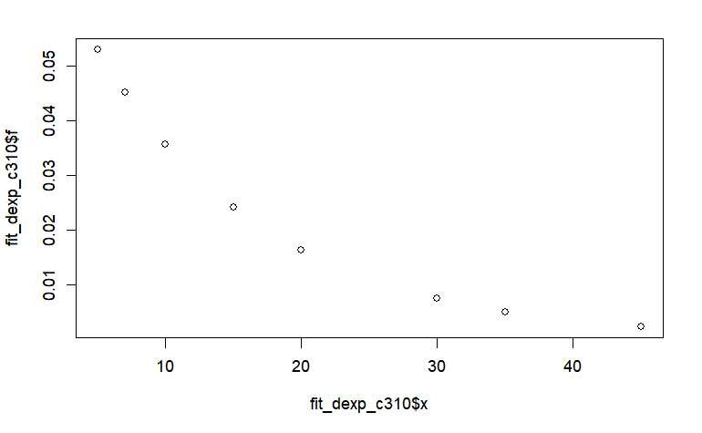

```r
fit_dexp_c310 <- data.frame(f = dexp(c_3_2010$DURATION, rate = exp_c3_2010_$estimate[1]),
                       x = c_3_2010$DURATION, type = "exp")

plot(x = fit_dexp_c310$x, y = fit_dexp_c310$f)
```

Now let’s compare these models AIC and BIC to see which fits the walk data best:

```r
#comparing these models AIC and BIC to see which fits the walk data best:
broom::glance(MASS::fitdistr(c_3_2010$DURATION%>% unlist() %>% as.numeric(),"gamma"))
```

| logLik | AIC | BIC | nobs |
| --- | --- | --- | --- |
| -78.5699 | 161.1398 | 163.3219 | 22 |

```r
broom::glance(MASS::fitdistr(c_3_2010$DURATION%>% unlist() %>% as.numeric(),"weibull"))
```

| logLik | AIC | BIC | nobs |
| --- | --- | --- | --- |
| -79.1341 | 162.2682 | 164.4503 | 22 |

```r
broom::glance(MASS::fitdistr(c_3_2010$DURATION%>% unlist() %>% as.numeric(),"exponential"))
```

| logLik | AIC | BIC | nobs |
| --- | --- | --- | --- |
| -81.0372 | 164.0744 | 165.1654 | 22 |

```r
cycling_310_exp <- exp_c3_2010_
c_3_2010 <- c_3_2010 %>%
 mutate(f_3 = dexp(DURATION, cycling_310_exp$estimate["rate"]))
summary(c_3_2010$f_3)
```

```
    Min.  1st Qu.   Median     Mean  3rd Qu.     Max.
0.002297 0.016336 0.035802 0.032751 0.053002 0.053002
```

###Destination : Cycling - Restaurant/bar (4), 2010

using a skew vs. kurtois graph to descriptive statistics of data

```r
# creating a skew vs. kurtois graph for cycling 2010

# Filter the data based on the "destination" column
 c_4_2010 <- cycling_2010 %>%
  filter(destination == "4")
count <- sum(cycling_2010$destination == "4")
print(count)
```

```
[1] 0
```

```r
#descdist(c_4_2010$DURATION %>% unlist() %>% as.numeric(), discrete=FALSE, boot=500)
```

###Destination : Cycling - Place of worship (5), 2010

using a skew vs. kurtois graph to descriptive statistics of data

```r
# creating a skew vs. kurtois graph for cycling 2010

# Filter the data based on the "destination" column
 c_5_2010 <- cycling_2010 %>%
  filter(destination == "5")
count <- sum(cycling_2010$destination == "5")
print(count)
```

```
[1] 0
```

```r
#descdist(c_5_2010$DURATION %>% unlist() %>% as.numeric(), discrete=FALSE, boot=500)
```

###Destination : Cycling - Grocery store, other stores or mall (6 ad 7), 2010

using a skew vs. kurtois graph to descriptive statistics of data

```r
# creating a skew vs. kurtois graph for cycling 2010

# Filter the data based on the "destination" column
 c_6_2010 <- cycling_2010 %>%
  filter(destination %in% c("6", "7"))
descdist(c_6_2010$DURATION %>% unlist() %>% as.numeric(), discrete=FALSE, boot=500)
```

[output not shown]

```r
# Based on the skew vs. kurtois graph the best distribution

#Calculating gamma distribution
gamma_c6_2010_ <- fitdistrplus::fitdist(data=c_6_2010$DURATION%>% unlist() %>% as.numeric(), "gamma", method="mle", optim.method="Nelder-Mead", weights = round(c_6_2010$WGHT_EPI))
fit_dgamma_c610 <- data.frame(f = dgamma(c_6_2010$DURATION, shape = gamma_c6_2010_$estimate[1], rate = gamma_c6_2010_$estimate[2]), x = c_6_2010$DURATION, type = "Gamma")

summary(gamma_c6_2010_)
```

```
Fitting of the distribution ' gamma ' by maximum likelihood
Parameters :
```

|  | estimate | Std. Error |
| --- | --- | --- |
| shape | 2.5012961 | 0.016443834 |
| rate | 0.1393649 | 0.001014314 |

```
Loglikelihood:  -151595.2   AIC:  303194.4   BIC:  303196.4
Correlation matrix:
         shape     rate
shape 1.000000 0.903195
rate  0.903195 1.000000
```

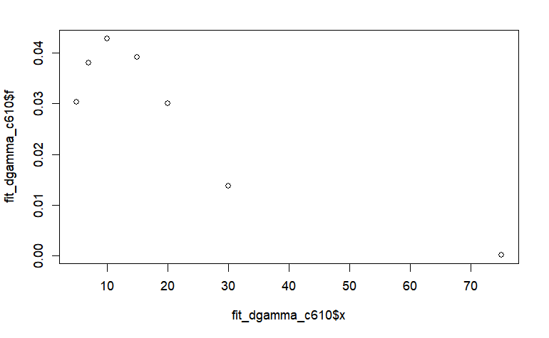

```r
plot(x= fit_dgamma_c610$x, y=fit_dgamma_c610$f)
```

```r
#Calculating normal distribution
norm_c6_2010_ <- fitdistrplus::fitdist(data=c_6_2010$DURATION%>% unlist() %>% as.numeric(), "norm", method="mle", optim.method="Nelder-Mead", weights = round(c_6_2010$WGHT_EPI))
summary(norm_c6_2010_)
```

```
Fitting of the distribution ' norm ' by maximum likelihood
Parameters :
```

|  | estimate | Std. Error |
| --- | --- | --- |
| mean | 17.94702 | 0.05889134 |
| sd | 11.91891 | 0.04164499 |

```
Loglikelihood:  -159626   AIC:  319256.1   BIC:  319258.1
Correlation matrix:
              mean            sd
mean  1.0000000000 -0.0001938448
sd   -0.0001938448  1.0000000000
```

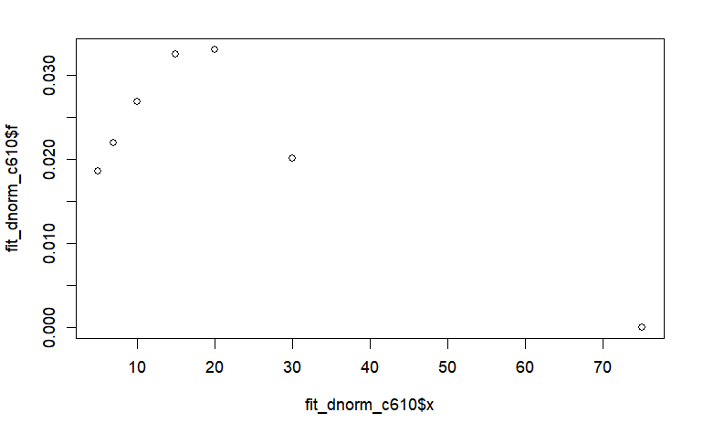

```r
fit_dnorm_c610 <- data.frame(f = dnorm(c_6_2010$DURATION, mean = norm_c6_2010_$estimate[1], sd = norm_c6_2010_$estimate[2]), x = c_6_2010$DURATION, type = "norm")

plot(x= fit_dnorm_c610$x, y=fit_dnorm_c610$f)
```

```r
#Calculating exponential distribution
exp_c6_2010_ <- fitdistrplus::fitdist(data=c_6_2010$DURATION%>% unlist() %>% as.numeric(), "exp", method="mle", optim.method="Nelder-Mead", weights = round(c_6_2010$WGHT_EPI))
summary(exp_c6_2010_)
```

```
Fitting of the distribution ' exp ' by maximum likelihood
Parameters :
```

|  | estimate | Std. Error |
| --- | --- | --- |
| rate | 0.05572456 | 0.0002752463 |

```
Loglikelihood:  -159236.5   AIC:  318475   BIC:  318476
```

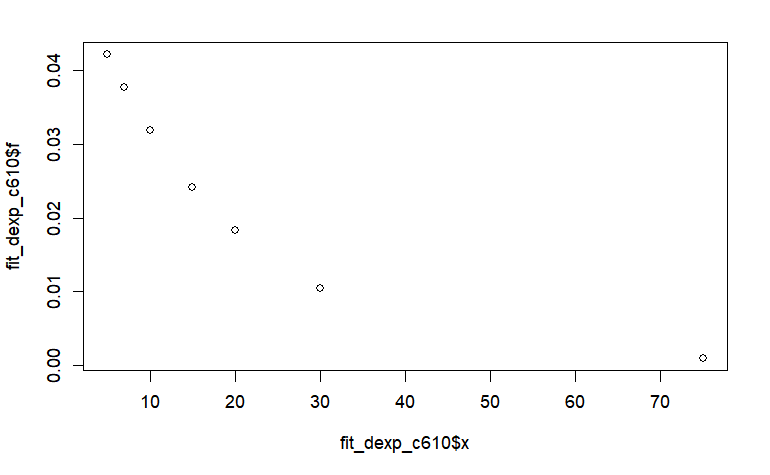

```r
fit_dexp_c610 <- data.frame(f = dexp(c_6_2010$DURATION, rate = exp_c6_2010_$estimate[1]),
                       x = c_6_2010$DURATION, type = "exp")

plot(x = fit_dexp_c610$x, y = fit_dexp_c610$f)
```

Now let’s compare these models AIC and BIC to see which fits the walk data best:

```r
#comparing these models AIC and BIC to see which fits the walk data best:
broom::glance(MASS::fitdistr(c_6_2010$DURATION%>% unlist() %>% as.numeric(),"gamma"))
```

| logLik | AIC | BIC | nobs |
| --- | --- | --- | --- |
| -74.31237 | 152.6247 | 154.6162 | 20 |

```r
broom::glance(MASS::fitdistr(c_6_2010$DURATION%>% unlist() %>% as.numeric(),"normal"))
```

| logLik | AIC | BIC | nobs |
| --- | --- | --- | --- |
| -83.24115 | 170.4823 | 172.4738 | 20 |

```r
broom::glance(MASS::fitdistr(c_6_2010$DURATION%>% unlist() %>% as.numeric(),"exponential"))
```

| logLik | AIC | BIC | nobs |
| --- | --- | --- | --- |
| -76.60536 | 155.2107 | 156.2064 | 20 |

So, gamma has largest logLik and the smallest AIC and BIC. we will pick gamma function for cycling trips in 2010!

```r
cycling_610_gamma <- gamma_c6_2010_
c_6_2010 <- c_6_2010 %>%
 mutate(f_6 = dgamma(DURATION, cycling_610_gamma$estimate["shape"],cycling_610_gamma$estimate["rate"] ))
summary(c_6_2010$f_6)
```

```
     Min.   1st Qu.    Median      Mean   3rd Qu.      Max.
0.0001025 0.0300584 0.0380458 0.0321345 0.0427843 0.0427843
```

###Destination :Outdoors (9)

using a skew vs. kurtois graph to descriptive statistics of data

```r
# creating a skew vs. kurtois graph for cycling 2010

# Filter the data based on the "destination" column
 c_9_2010 <- cycling_2010 %>%
  filter(destination == "9")
count <- sum (cycling_2010$destination == "9")
print(count)
```

```
[1] 7
```

```
summary statistics
------
min:  3   max:  20
median:  10
mean:  9.714286
estimated sd:  6.102302
estimated skewness:  0.7430846
estimated kurtosis:  2.645881
```

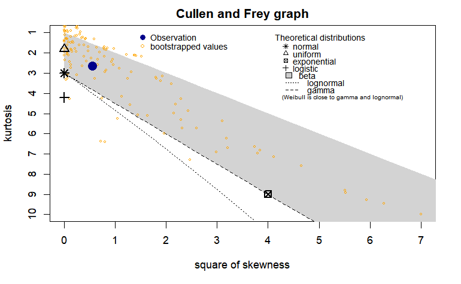

```r
descdist(c_9_2010$DURATION %>% unlist() %>% as.numeric(), discrete=FALSE, boot=500)
```

```r
# Based on the skew vs. kurtois graph the best distribution

#Calculating gamma distribution
gamma_c9_2010_ <- fitdistrplus::fitdist(data=c_9_2010$DURATION%>% unlist() %>% as.numeric(), "gamma", method="mle", optim.method="Nelder-Mead", weights = round(c_9_2010$WGHT_EPI))
fit_dgamma_c910 <- data.frame(f = dgamma(c_9_2010$DURATION, shape = gamma_c9_2010_$estimate[1], rate = gamma_c9_2010_$estimate[2]), x = c_9_2010$DURATION, type = "Gamma")

summary(gamma_c9_2010_)
```

```
Fitting of the distribution ' gamma ' by maximum likelihood
Parameters :
```

|  | estimate | Std. Error |
| --- | --- | --- |
| shape | 2.5234575 | 0.031993308 |
| rate | 0.2321712 | 0.003255949 |

```
Loglikelihood:  -35244.26   AIC:  70492.53   BIC:  70492.42
Correlation matrix:
          shape      rate
shape 1.0000000 0.9040249
rate  0.9040249 1.0000000
```

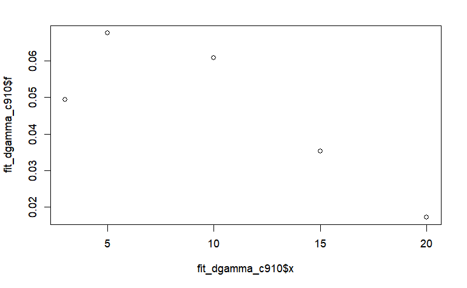

```r
plot(x= fit_dgamma_c910$x, y=fit_dgamma_c910$f)
```

```r
#Calculating normal distribution
norm_c9_2010_ <- fitdistrplus::fitdist(data=c_9_2010$DURATION%>% unlist() %>% as.numeric(), "norm", method="mle", optim.method="Nelder-Mead", weights = round(c_9_2010$WGHT_EPI))
summary(norm_c9_2010_)
```

```
Fitting of the distribution ' norm ' by maximum likelihood
Parameters :
```

|  | estimate | Std. Error |
| --- | --- | --- |
| mean | 10.870818 | 0.05944704 |
| sd | 6.242222 | 0.04202946 |

```
Loglikelihood:  -35838.57   AIC:  71681.14   BIC:  71681.03
Correlation matrix:
             mean           sd
mean 1.0000000000 0.0003418412
sd   0.0003418412 1.0000000000
```

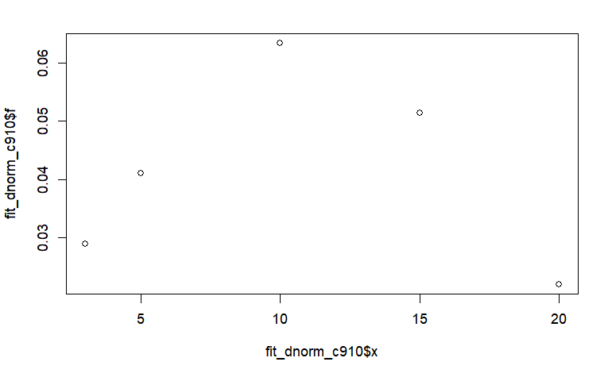

```r
fit_dnorm_c910 <- data.frame(f = dnorm(c_9_2010$DURATION, mean = norm_c9_2010_$estimate[1], sd = norm_c9_2010_$estimate[2]), x = c_9_2010$DURATION, type = "norm")

plot(x= fit_dnorm_c910$x, y=fit_dnorm_c910$f)
```

```r
#Calculating poisson distribution
pois_c9_2010_ <- fitdistrplus::fitdist(data=c_9_2010$DURATION%>% unlist() %>% as.numeric(), "pois", method="mle", optim.method="Nelder-Mead", weights = round(c_9_2010$WGHT_EPI))
summary(pois_c9_2010_)
```

```
Fitting of the distribution ' pois ' by maximum likelihood
Parameters :
```

|  | estimate | Std. Error |
| --- | --- | --- |
| lambda | 10.86975 | 0.03139856 |

```
Loglikelihood:  -43173.43   AIC:  86348.86   BIC:  86348.81
```

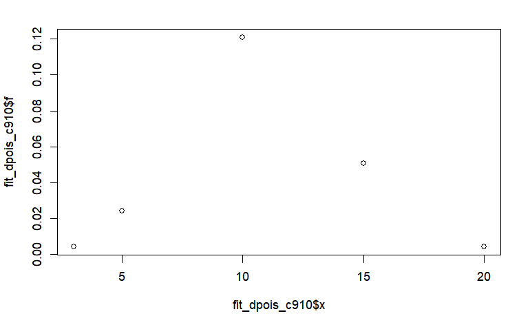

```r
fit_dpois_c910 <- data.frame(f = dpois(c_9_2010$DURATION, lambda = pois_c9_2010_$estimate[1]), x = c_9_2010$DURATION, type = "pois")

plot(x= fit_dpois_c910$x, y=fit_dpois_c910$f)
```

```r
#Calculating exponential distribution
exp_c9_2010_ <- fitdistrplus::fitdist(data=c_9_2010$DURATION%>% unlist() %>% as.numeric(), "exp", method="mle", optim.method="Nelder-Mead", weights = round(c_9_2010$WGHT_EPI))
summary(exp_c9_2010_)
```

```
Fitting of the distribution ' exp ' by maximum likelihood
Parameters :
```

|  | estimate | Std. Error |
| --- | --- | --- |
| rate | 0.09136029 | 0.0008699543 |

```
Loglikelihood:  -37333.68   AIC:  74669.36   BIC:  74669.3
```

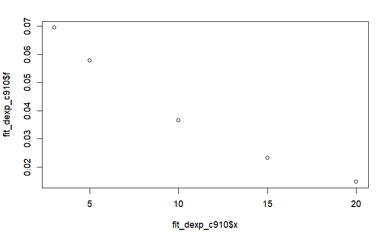

```r
fit_dexp_c910 <- data.frame(f = dexp(c_9_2010$DURATION, rate = exp_c9_2010_$estimate[1]),
                       x = c_9_2010$DURATION, type = "exp")

plot(x = fit_dexp_c910$x, y = fit_dexp_c910$f)
```

Now let’s compare these models AIC and BIC to see which fits the walk data best:

```r
#comparing these models AIC and BIC to see which fits the walk data best:
broom::glance(MASS::fitdistr(c_9_2010$DURATION%>% unlist() %>% as.numeric(),"gamma"))
```

| logLik | AIC | BIC | nobs |
| --- | --- | --- | --- |
| -21.27006 | 46.54013 | 46.43195 | 7 |

```r
broom::glance(MASS::fitdistr(c_9_2010$DURATION%>% unlist() %>% as.numeric(),"normal"))
```

| logLik | AIC | BIC | nobs |
| --- | --- | --- | --- |
| -22.05371 | 48.10741 | 47.99923 | 7 |

```r
broom::glance(MASS::fitdistr(c_9_2010$DURATION%>% unlist() %>% as.numeric(),"poisson"))
```

| logLik | AIC | BIC | nobs |
| --- | --- | --- | --- |
| -25.20582 | 52.41164 | 52.35755 | 7 |

```r
broom::glance(MASS::fitdistr(c_9_2010$DURATION%>% unlist() %>% as.numeric(),"exponential"))
```

| logLik | AIC | BIC | nobs |
| --- | --- | --- | --- |
| -22.91518 | 47.83037 | 47.77628 | 7 |

So, gamma has largest logLik and the smallest AIC and BIC. we will pick gamma function for cycling trips in 2010!

```r
cycling_910_gamma <- gamma_c9_2010_
c_9_2010 <- c_9_2010 %>%
 mutate(f_9 = dgamma(DURATION, cycling_910_gamma$estimate["shape"], cycling_910_gamma$estimate["rate"] ))
summary(c_9_2010$f_9)
```

```
   Min. 1st Qu.  Median    Mean 3rd Qu.    Max.
0.01715 0.04233 0.06080 0.05121 0.06417 0.06753
```

###Destination :Library (10)

using a skew vs. kurtois graph to descriptive statistics of data

```r
# creating a skew vs. kurtois graph for cycling 2010

# Filter the data based on the "destination" column
 c_10_2010 <- cycling_2010 %>%
  filter(destination == "10")
count <- sum(cycling_2010$destination == "10")
print(count)
```

```
[1] 0
```

```r
#descdist(c_10_2010$DURATION %>% unlist() %>% as.numeric(), discrete=FALSE, boot=500)
```

creating a new walking data frame that have all the f values for walking 2010

```r
walking_2010_f <- bind_rows(w_1_2010, w_2_2010, w_3_2010, w_4_2010, w_5_2010, w_6_2010, w_9_2010, w_10_2010)
```

creating a new cycling data frame that have all the f values for cycling 2010

```r
cycling_2010_f <- bind_rows(c_1_2010, c_2_2010, c_3_2010, c_6_2010, c_9_2010)
```